# Survival Analysis

# Introduction

What is survival analysis and how is it different from other types of analysis? Survival analysis Survival analysis focuses on time until an event occurs. This event (represented by a categorical variable typically) is a qualitative change that is tied to a specific point in time. Survival analysis was originally designed for medical studies and the occurrence of death - hence the name. However, many more fields are interested in survival analysis. Other names that people use to describe survival analysis are time-to-event analysis, duration analysis, and failure analysis.

This markdown file contains information on how to perform survival analysis and all of its components in SAS and R. In each section you are able to toggle back and forth between the code and output you desire to view.

The first thing that we need to do is load up all of the needed libraries in R that we will be using. This isn’t needed for the SAS sections of the code.

```r
install.packages("survival")
install.packages("survminer")
install.packages("flexsurv")
install.packages("visreg")
install.packages("ggplot2")
install.packages("MASS")

library(survival)
library(survminer)
library(flexsurv)
library(visreg)
library(ggplot2)
library(MASS)
```

# Censoring, Survival, and Hazards

In survival analysis, the target variable is actually two pieces - one continuous and one categorical:

1. **Time**: tenure for an observation (continuous)
2. **Event/status**: at the end of that time, what happened? (categorical)

Survival analysis has a target variable that is typically broken into two pieces - occurrence of an event and time until the event. Here, “time” generally refers to **tenure** rather than actual calendar time. The “event” is some specific outcome of interest such as a customer cancelling service, a customer making another purchase, a patient developing a disease, or a customer defaulting on a loan. Unlike classification models (logistic regression for example) that just focus on whether an event happened, survival analysis also desires to understand how long before the event happened if the event happened at all.

One might think that we then have a typical continuous target variable problem and linear regression with ordinary least squares (OLS) would suffice. However, the biggest problem with using OLS for time-to-event data is that not all observations have experienced the event. This is called **censoring**. Another problem with traditional OLS regression is that tenure must always be positive which makes satisfying the normality assumption of the residuals difficult. Also, the risk of failure (not surviving) could easily change across time, which OLS cannot account for. Instead, you can imagine survival analysis as a classification problem predicting probability of an event across time.

We will be using a Maryland recidivism data set from a study done in the 1970’s to model the association between various factors and the length of time before the possible event of rearrest within one year. Of the 432 men in the study, 114 of them were rearrested within one year. The variables in the data set are the following:

Maryland Recidivism Data Dictionary

| Variable | Description |
| --- | --- |
| week | week of arrest; week = 52 if not arrested (censored) |
| arrest | indicator for arrest (1 = yes, 0 = no) |
| fin | received financial aid upon release (1 = yes, 0 = no) |
| age | age at time of release (years) |
| race | indicator for Black (1 = yes, 0 = no) |
| wexp | indicator of prior work full time work experience |
| prior to incarceration (1 = yes, 0 = no) |  |
| mar | married at time of release (1 = yes, 0 = no) |
| paro | released on parole (1 = yes, 0 = no) |
| prio | number of prior convictions |

## Time & Censoring

Survival analysis has a few things that set it apart from any other statistical modeling approaches:

- Time to an event
- Censoring

Just like most models, survival analysis depends on certain assumptions. One of the big assumptions is defining when time starts. In survival analysis, we create an artificial world in which everyone “starts” at the same time. This goes back to our interest in tenure instead of time. These are both compared in the following figure:

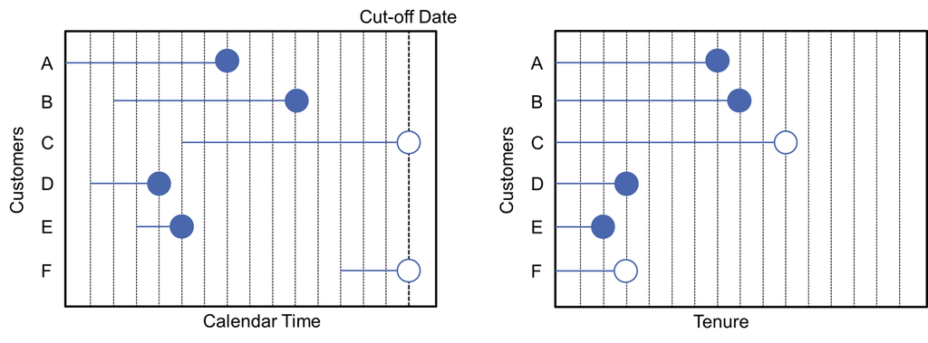

Time vs. Tenure

This choice of a starting point in time isn’t always obvious. Here are some examples of this problem from different fields:

- Time since exposure to disease vs. developing the disease for medical studies
- Time since diagnosis vs. surgery vs. treatment for hospital readmissions or recovery
- Time since a previous or different event
- Time until car breaks from production vs. purchase vs. last repair

Interested in time to event $T$, but we can not observe this for all observations since not all observations have had or even won’t ever have the event. These observations are called **censored**. The tenure we actually observe for each observation *i* is the minimum between the time to the event ($T_i$) or the censoring time ($C_i$). The corresponding categorical variable informs us which one of these we observe for each observation.

However, a censored observation is **not** a missing observation. We do not know the actual time $T_i$ for the censored observations, but we **do** know that for some amount of time - namely $C_i$ - the event has not occurred. This provides some but not all information about $T-i$. Censoring data is incomplete rather than missing. Ignoring censored observations would be falsely acting as if we know nothing about $T_i$.

There are different variations of censoring. First let’s talk about Type I vs. Type II censoring.

- **Type I** (most common): there is a specific end time $c$, and any subject that hasn’t had the event by time $c$ is censored
- **Type II**: time goes until a certain (pre-specified) number of events have occurred, and any subjects who haven’t had the event by that time are censored

While Type I vs. Tyype II censoring is one distinction for censoring, another distinction is right, left, or interval censoring.

- **Right** (most common): the event time $T_i > c$
  - Example: Customer has monthly subscription for at least 3 months
- **Left**: the event time $T_i < c$
  - Example: Patient joined a medical study after already having the disease
- **Interval**: the event time is between two bounds $a < T_i < b$
  - Example: Person tests negative during appointment at $a$, but positive during appointment at $b$ so disease was developed in between

The last distinction for censoring involves an assumption around independence. First, we must distinguish between fixed and random censoring.

- **Fixed**: censoring only occurs at the end of the study ($C_i = c$ is known in advance)
  - Example: Not arrested in 52 weeks is censored by design as that is when the study ended
- **Random**: censoring time $C_i$ may vary between subjects for reasons beyond the investigator’s control
  - Example: Not arrested within first 30 weeks, but left study for unknown reason

Typically, we assume the the event time $T_i$ and the censoring time $C_i$ are independent. That implies that subjects censored at time $t$ were randomly selected to be censored from all subjects still in the risk set at that time. If this is true, then there is no mathematical difference between random and fixed censoring as defined above. However, if that assumption is **not** true, then there is a difference between fixed and random censoring that needs to be accounted for. These are dealt with in the section on competing risks.

## Survival Function

When it comes to survival data we are interested in the event time $T$. There are some unique challenges to summarizing information about $T$. We know that $T$ is bounded at zero and most likely right skewed. That means that variances and averages are not the best form of summarizing. When censoring is present, are averages and variances aren’t even as meaningful since we don’t fully know all the values of $T$. Instead, we focus on two typical functions to summarize survival data - the survival function and the hazard function.

The **survival function** is the probability of surviving *beyond* time $t$:

$$S(t) = P(T>t)$$
This function always starts at 1 (or 100%) when the time equals 0 and bounded below by 0. This function also never increases as once observations have had the event, they are no longer considered as survived. These curves are the foundation of the field of survival analysis.

The Kaplan-Meier (KM) method is the primary way we estimate survival functions. We want to estimate the proportion of observations that have yet to experience the event at any given time $t$. The KM method calculates the survival function as follows:

$$\hat{S}(t) = \Pi_{k \le t} (1 - \frac{d_{k}}{r_{k}})$$
In the above equation, $d_{k}$ is the number of events occurring at time $t$, while $r_{k}$ is the number of observations “at risk” of having the event right before time $t$. The KM method has actually existed long before Kaplan and Meier, but Kaplan and Meier showed it was the maximum likelihood estimate for the nonparametric estimation of the survival curve.

Let’s see how to produce these in each of our softwares using the simple data set we have in the picture below. Then we will use our prisoner recidivism data set.

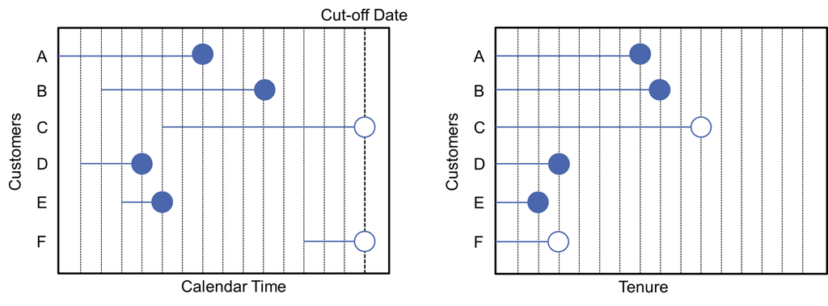

Time vs. Tenure

### SAS

Let’s look at the survival function for the above visualized data set of six customers. Customers C and F were censored, while customers A, B, D, and E had the events.

We have created those six observations using the DATA step below. PROC LIFETEST is then used to calculate the survival curve. The `data =` option specifies the data set we are using. The `time` statement specifies the two pieces of our target variable that we are mapping the survival curve for. The first piece is the time (or tenure) component called *Tenure* in our data set. The next piece is the variable flagging censored observations called *censored* in our data set. The value in the parantheses signifies the observations that are censored. Note that this is different than R which specifies the observations that are *not* censored.

```
data Simple;
    input Customer $ Tenure censored;
datalines;
A 7 0
B 8 0
C 10 1
D 3 0
E 2 0
F 3 1
;

proc lifetest data=Simple;
    time Tenure*censored(1);
run;
```

| Product-Limit Survival Estimates Tenure | Product-Limit Survival Estimates | Product-Limit Survival Estimates Survival | Product-Limit Survival Estimates Failure | Product-Limit Survival Estimates Survival Standard Error | Product-Limit Survival Estimates Number Failed | Product-Limit Survival Estimates Number Left |
| --- | --- | --- | --- | --- | --- | --- |
| 0.0000 |  | 1.0000 | 0 | 0 | 0 | 6 |
| 2.0000 |  | 0.8333 | 0.1667 | 0.1521 | 1 | 5 |
| 3.0000 |  | 0.6667 | 0.3333 | 0.1925 | 2 | 4 |
| 3.0000 | * | . | . | . | 2 | 3 |
| 7.0000 |  | 0.4444 | 0.5556 | 0.2222 | 3 | 2 |
| 8.0000 |  | 0.2222 | 0.7778 | 0.1925 | 4 | 1 |
| 10.0000 | * | . | . | . | 4 | 0 |

| Note: | The marked survival times are censored observations. |
| --- | --- |

| Summary Statistics for Time Variable Tenure |
| --- |

| Quartile Estimates Percent | Quartile Estimates Point Estimate | Quartile Estimates 95% Confidence Interval Transform | Quartile Estimates 95% Confidence Interval [Lower | Quartile Estimates 95% Confidence Interval Upper) |
| --- | --- | --- | --- | --- |
| 75 | 8.0000 | LOGLOG | 3.0000 | . |
| 50 | 7.0000 | LOGLOG | 2.0000 | . |
| 25 | 3.0000 | LOGLOG | 2.0000 | 8.0000 |

| Mean | Standard Error |
| --- | --- |
| 5.9444 | 1.1750 |

| Note: | The mean survival time and its standard error were underestimated because the largest observation was censored and the estimation was restricted to the largest event time. |
| --- | --- |

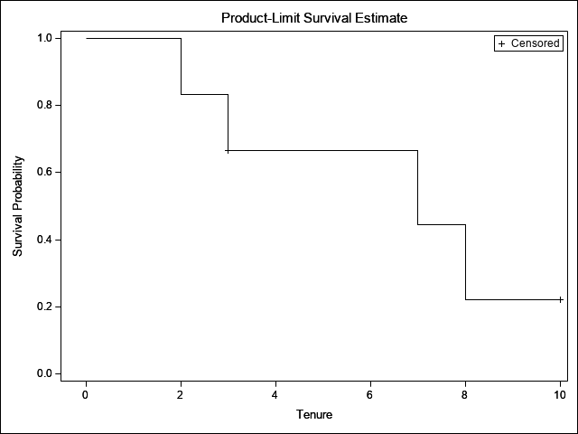

| Summary of the Number of Censored and Uncensored Values Total | Summary of the Number of Censored and Uncensored Values Failed | Summary of the Number of Censored and Uncensored Values Censored | Summary of the Number of Censored and Uncensored Values Percent Censored |
| --- | --- | --- | --- |
| 6 | 4 | 2 | 33.33 |

SAS will provide a table listing all of the values in the survival curve. Since our data set only has six observations, this is rather small. However, be careful with large datasets as this table can grow rather quickly. At time 0, we can see that the survival curve equals 1 since all observations have not had the event at time zero. At time 2, our first observation (E) has the event, dropping the survival function to 0.8333. At time 3 we have a couple of things happening. First, we have another observation (D) with the event so our survival curve drops to 0.6667. However, F is censored at this time point. That does mean that F didn’t have the event at time 3, but isn’t around until time 4 so although our number of events stays at 2, the number at risk drops from 4 to 3 since F is no longer at risk right after time 3. Times 7 and 8 also see drops in the survival function since observations A and B had the events at those times respectively. Lastly, observation C is censored at time point 10 which means that the number at risk is now 0 which stops the calculation of the survival curve.

SAS also provides some summary statistics around our data too. It provides the quartiles as well as the mean. As mentioned above, the mean isn’t as valuable here since we have censored observations. However, the median is still valid as long as the event occurs for more than half of the sample. This point on the survival curve is also called the data set’s *half-life*. This is the point where half of the observations survive beyond that time $t$.

Lastly, SAS also provides the visual of the survival curve.

Let’s see this same output for the prisoner recidivism data set. Our time variable here is *week* while our censoring variable is *arrest* with the 0 marking that the person was not rearrested which is a censored observation. Note, the calculation table of the survival curve has been suppressed with the `notable` option due to its length.

```
proc lifetest data = Survival.Recid notable;
    time week*arrest(0);
run;
```

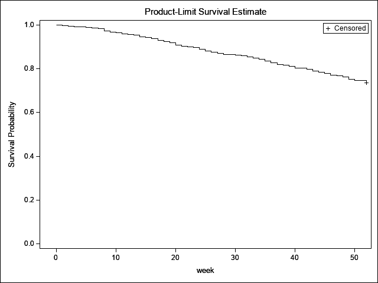

| Summary of the Number of Censored and Uncensored Values Total | Summary of the Number of Censored and Uncensored Values Failed | Summary of the Number of Censored and Uncensored Values Censored | Summary of the Number of Censored and Uncensored Values Percent Censored |
| --- | --- | --- | --- |
| 432 | 114 | 318 | 73.61 |

### R

Let’s look at the survival function for the above visualized data set of six customers. Customers C and F were censored, while customers A, B, D, and E had the events.

We have created those six observations using the first four lines of code below by putting them into a data frame called *simple*. The `Surv` function is then used to create our survival object, which R needs to build survival models off of. This survival object specifies the two pieces of our target variable that we are mapping the survival curve for. The first piece is the `time =` option (or tenure) component called *tenure* in our data set. The next piece is the `event =` option flagging censored observations called *censored* in our data set. The value in the parantheses signifies the observations that are *not* censored. Note that this is different than SAS which specifies the observations that *are* censored.

The `survfit` function will then calculate the KM estimate of the survival curve. We take our survival object `recid_simple` and put it in a formula with `~ 1` afterwards. We will use this formula in later sections to stratify our analysis. We also use the `data =` option to specify our data set. The `summary` and `plot` functions will then display our results in a table and plot respectively.

```r
customer <- c("A", "B", "C", "D", "E", "F")
tenure <- c( 7, 8, 10, 3, 2, 3)
censored <- c(0, 0, 1, 0, 0, 1)

simple <- data.frame(customer, tenure, censored)

recid_simple <- Surv(time = simple$tenure, event = simple$censored == 0)

simple_km <- survfit(recid_simple ~ 1, data = simple)
summary(simple_km)
```

```
Call: survfit(formula = recid_simple ~ 1, data = simple)

 time n.risk n.event survival std.err lower 95% CI upper 95% CI
    2      6       1    0.833   0.152       0.5827            1
    3      5       1    0.667   0.192       0.3786            1
    7      3       1    0.444   0.222       0.1668            1
    8      2       1    0.222   0.192       0.0407            1
```

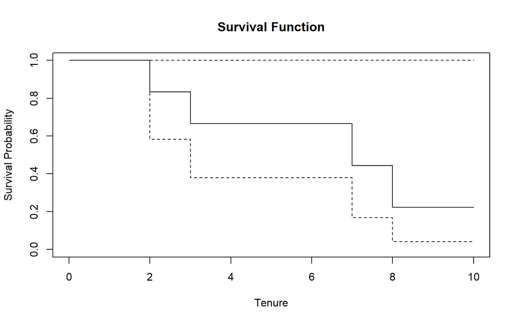

```r
plot(simple_km, main = "Survival Function", xlab = "Tenure", ylab = "Survival Probability")
```

R will provide a table listing all of the values in the survival curve. Since our data set only has six observations, this is rather small. However, be careful with large datasets as this table can grow rather quickly. At time 2, our first observation (E) has the event, dropping the survival function from 1 to 0.8333. At time 3 we have a couple of things happening. First, we have another observation (D) with the event so our survival curve drops to 0.6667. However, F is censored at this time point. That does mean that F didn’t have the event at time 3, but isn’t around until time 4 so although our number of events stays at 2, the number at risk drops from 4 to 3 since F is no longer at risk right after time 3. Times 7 and 8 also see drops in the survival function since observations A and B had the events at those times respectively. Lastly, observation C is censored at time point 10 which means that the number at risk is now 0 which stops the calculation of the survival curve.

Lastly, R also provides the visual of the survival curve.

Let’s see this same output for the prisoner recidivism data set. Our time variable here is *week* while our censoring variable is *arrest* with the 0 marking that the person was not rearrested which is a censored observation. Note, the calculation table of the survival curve has been suppressed by commenting out the `summary` function due to the table’s length.

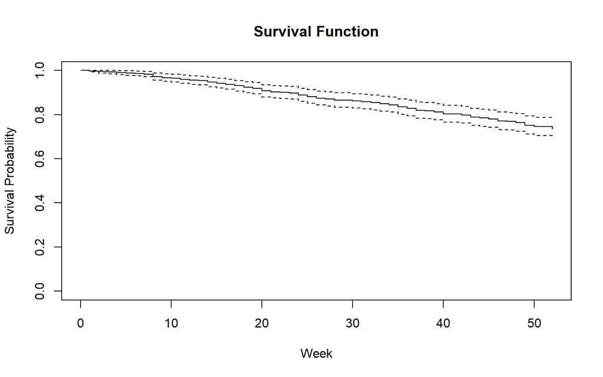

```r
recid_surv <- Surv(time = recid$week, event = recid$arrest == 1)

recid_km <- survfit(recid_surv ~ 1, data = recid)
#summary(recid_km)
plot(recid_km, main = "Survival Function", xlab = "Week", ylab = "Survival Probability")
```

A `gplot` version of the survival function can also be obtained with the `ggsurvplot` function in R. The input is a `Surv` object. The `data =` option specifies the data set and the `conf.int =` specifies if a confidence interval is shown. The rest of the options shown below are for visual appeal.

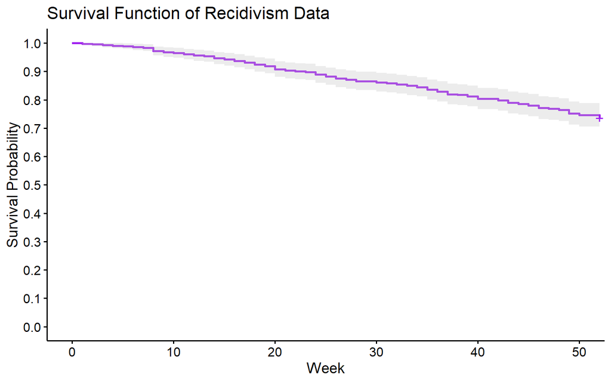

```r
ggsurvplot(recid_km, data = recid, conf.int = TRUE, palette = "purple",
           xlab = "Week", ylab = "Survival Probability", legend = "none",
           title = "Survival Function of Recidivism Data", break.y.by = 0.1)
```

## Stratified Analysis

Instead of just focusing on one survival curve for the entire sample, we can also split our sample into smaller groups that we think might have different survival curves. We can also statistically test these groups’ survival curves to see if they are the same or not. The primary tests that are used are the Log-Rank test (developed by Mantel and Haenszel) and the Wilcoxon test.

The Log-Rank test combines all the information from the KM estimate at times where events occur. Similar to the Mantel-Haenszel Chi-square test, the Log-rank test then looks for an association in the counts of a cross-tabulation table. The columns of the table are the number of events and number of non-events in each of the rows which are the groups you are subsampling down into. The actual data is compared to the expected values in each cell to develop a Chi-square test statistic:

$$LogRank = \frac{1}{\hat{\sigma}^2}\times (\sum_{j=1}^r(d_{1,j} - e_{1,j}))^2$$
The Wilcoxon test adds a weight to the above Chi-square test to adjust for differences in sample size along the curve. Since fewer observations exist the further in time you are, the observations at the beginning of the curve are weighted heavier based on this sample size:

$$Wilcoxon = \frac{1}{\hat{\sigma}^2}\times (\sum_{j=1}^r(d_{1,j} - e_{1,j})n_{j})^2$$
Let’s see how to produce these in each of our softwares!

### SAS

Again, SAS uses the PROC LIFETEST prodecure to compute the survival curves. The only addition to this code is the `strata` statement. Here is the `strata` statement specifies the variable you want to stratify your data on. We are using the *wexp* variable to stratify our observations by those who do and do not have previous work experience. As before, the `notable` option has been used (as well ODS statements) to not display the entire survival tables for both the strata.

```
ods select html HomTests CensoredSummary SurvivalPlot;
proc lifetest data = Survival.Recid plots=s(cl cb=ep) notable;
    time week*arrest(0);
    strata wexp;
run;
```

| Summary of the Number of Censored and Uncensored Values Stratum | Summary of the Number of Censored and Uncensored Values wexp | Summary of the Number of Censored and Uncensored Values Total | Summary of the Number of Censored and Uncensored Values Failed | Summary of the Number of Censored and Uncensored Values Censored | Summary of the Number of Censored and Uncensored Values Percent Censored |
| --- | --- | --- | --- | --- | --- |
| 1 | 0 | 185 | 62 | 123 | 66.49 |
| 2 | 1 | 247 | 52 | 195 | 78.95 |
| Total |  | 432 | 114 | 318 | 73.61 |

| Test of Equality over Strata Test | Test of Equality over Strata Chi-Square | Test of Equality over Strata DF | Test of Equality over Strata Pr > Chi-Square |
| --- | --- | --- | --- |
| Log-Rank | 9.9104 | 1 | 0.0016 |
| Wilcoxon | 10.9815 | 1 | 0.0009 |
| -2Log(LR) | 9.0608 | 1 | 0.0026 |

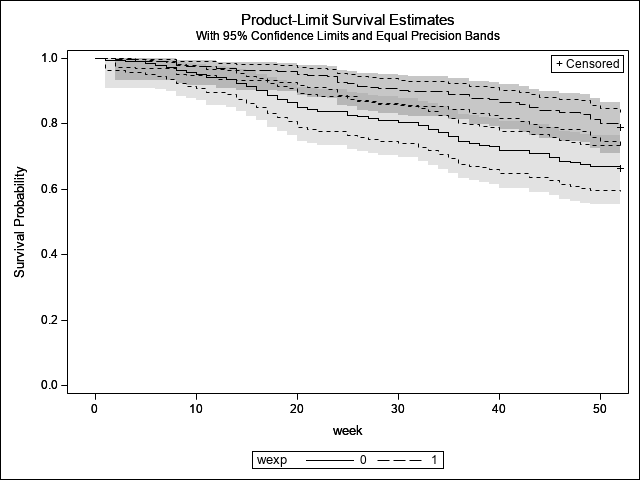

First, SAS provides us a summary of the two strata with how many events and censored observations we have in each. Next, we have the test of equality. The null hypothesis from each of these tests is the same - that the curves are *not* statistically different than each other. A reasonable significance level for our data is 0.014 and both the log-rank and the Wilcoxon test are significant at this level implying the curves are statistically different. Note, the Likelihood Ratio Test (LRT) is not best used here as it assumes our data follows an exponential distribution which we have not tested. The Log-Rank and Wilcoxon tests do not make an assumption about our data’s distribution. We then see the plot of each of the survival curves along with their respective confidence intervals.

If you had more than two groups, the overall test of significance won’t provide all the detail you need. By using the `diff = all` option as seen below, you can get pairwise adjusted statistical tests for all combinations of strata. The output is not different since we have two groups.

```
ods select html SurvDiff;
proc lifetest data = Survival.Recid plots=s(cl cb=ep) notable;
    time week*arrest(0);
    strata wexp / diff=all;
run;
```

| Adjustment for Multiple Comparisons for the Logrank Test Strata Comparison wexp | Adjustment for Multiple Comparisons for the Logrank Test Strata Comparison wexp | Adjustment for Multiple Comparisons for the Logrank Test Chi-Square | Adjustment for Multiple Comparisons for the Logrank Test p-Values Raw | Adjustment for Multiple Comparisons for the Logrank Test p-Values Tukey-Kramer |
| --- | --- | --- | --- | --- |
| 0 | 1 | 9.9104 | 0.0016 | 0.0016 |

| Adjustment for Multiple Comparisons for the Wilcoxon Test Strata Comparison wexp | Adjustment for Multiple Comparisons for the Wilcoxon Test Strata Comparison wexp | Adjustment for Multiple Comparisons for the Wilcoxon Test Chi-Square | Adjustment for Multiple Comparisons for the Wilcoxon Test p-Values Raw | Adjustment for Multiple Comparisons for the Wilcoxon Test p-Values Tukey-Kramer |
| --- | --- | --- | --- | --- |
| 0 | 1 | 10.9815 | 0.0009 | 0.0009 |

### R

R uses the `survdiff` function to statistically compare the survival functions. We have the `recid_surv` survival object from earlier but now we specify `~ wexp` to stratify by the *wexp* variable. We are using the *wexp* variable to stratify our observations by those who do and do not have previous work experience. The `rho = 0` option specifies the use of the Log-Rank test. If you desire the Wilcoxon test instead you can use `rho = 1`.

```r
survdiff(recid_surv ~ wexp, rho = 0, data = recid)
```

```
Call:
survdiff(formula = recid_surv ~ wexp, data = recid, rho = 0)

         N Observed Expected (O-E)^2/E (O-E)^2/V
wexp=0 185       62     45.6      5.91      9.91
wexp=1 247       52     68.4      3.94      9.91

 Chisq= 9.9  on 1 degrees of freedom, p= 0.002
```

The null hypothesis from each of these tests is the same - that the curves are *not* statistically different than each other. A reasonable significance level for our data is 0.014 and the log-rank test is significant at this level implying the curves are statistically different.

Again, R uses the `survfit` function to compute the survival curves. The only addition to this code is the `~ wexp` instead of `~ 1` in the formula. This specifies the variable you want to stratify your data on. As before, the `summary` function has been commented out to not display the entire survival tables for both the strata. Instead, we just graph them with the `ggsurplot` function created from our `recid_strat` object.

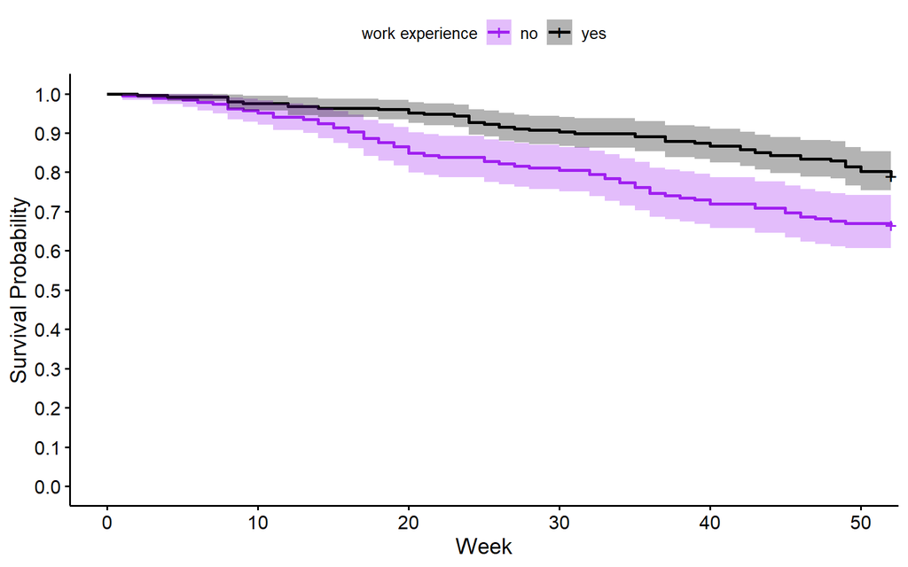

```r
recid_strat <- survfit(recid_surv ~ wexp, data = recid)
#summary(recid_strat)

ggsurvplot(recid_strat, data = recid, conf.int = TRUE, palette = c("purple", "black"),
           xlab = "Week", ylab = "Survival Probability", break.y.by = 0.1,
           legend.title = "work experience", legend.labs = c("no", "yes"))
```

If you had more than two groups, the overall test of significance won’t provide all the detail you need. By using the `pairwise_survdiff` function as seen below, you can get pairwise adjusted statistical tests for all combinations of strata. The output is not different since we have two groups.

```r
pairwise_survdiff(recid_surv ~ wexp, rho = 0, data = recid)
```

```
    Pairwise comparisons using Log-Rank test

data:  recid and wexp

  0
1 0.0016

P value adjustment method: BH
```

## Hazard Function

Outside of survival functions, the other primary function used in survival analysis is the **hazard function**. There are actually two types of hazard functions - hazard probabilities and hazard rates. Both are denoted the same way across different papers and texts so be careful!

Hazard probabilities are very useful and common in business settings. They define a conditional probability. Given that an observation has not experienced the event before time $t$, what is the probability that they experience the event before time $t+1$. It is defined as follows:

$$h(t) = P(t<T<t+1|T>t) = \frac{d_t}{r_t}$$
Notice that this is the ratio contained in the right hand side of the survival function calculation by Kaplan and Meier.

Hazard rates on the other hand have a slightly different use and interpretation because they are limits of conditional probabilities are follows:

$$h(t) = \lim_{\Delta t \rightarrow 0}\frac{P(t<T<t+\Delta t|T>t)}{\Delta t}$$
The hazard rate is the instantaneous event rate for the risk set at time $t$. Essentially, given survival up until time $t$, it is the rate of events in the interval $[t, t+\Delta t)$. Although they are bounded below by 0, since these are not probabilities, they are not bounded above by 1. For example, if the hazard rate for contracting a sinus infection is 0.05 with a time measured in months, then you are expected to contract 0.05 sinus infections in the next month (assuming the hazard stays constant). Maybe the inverse is more interpretable. Given that same hazard rate, you could also say that you expect to make it 20 (= 1/0.05) months before contracting your next sinus infection (assuming the hazard stays constant).

Sometimes, we also visualize the **cumulative hazard probability**, $\Lambda(t)$, which is just the cumulative hazard rate up until time $t$.

The survival, hazard, and cumulative hazard functions are all related to each other. These three quantities are all different ways of describing the same distribution. If you know one of them you can compute the others as follows:

- $\Lambda(t) = -\log S(t)$
- $S(t) = e^{-\Lambda (t)}$
- $h(t) = -\frac{d}{dt}\log S(t) = \frac{f(t)}{S(t)}$

Let’s see how to produce these in each of our softwares!

### SAS

SAS uses PROC LIFETEST to also calculate the hazard function. However, it uses a different technique beyond the KM method to do so. To get the hazard rates and probabilties from SAS, you need to use the actuarial method for calculation. Traditionally, the actuarial method bins time points into intervals to smooth out the estimates of the survival and hazard functions for large data sets. This is still a useful approach for data sets with many time points. For our simple data set (the one with customers A through F), we will calculate this for every time point.

In PROC LIFETEST we use the `method = life` option in SAS to specify the actuarial method with a `width = 1` option to keep the calculation per time point. This function will again give us the calculation of survival for each time point as well as the hazard rates (called hazard) and hazard probabilities (called conditional probabilities of failure). SAS will provide the graph of hazard rates by default. The `ods` statement takes the life table estimates from SAS and saves them into a new data set called `condprob` which we use in the PROC SGPLOT procedure to plot the hazard probabilities.

```
proc lifetest data = Simple method = life width = 1 plots(only)=hazard;
    time tenure*censored(1);
    ods output LifetableEstimates = condprob;
run;

proc sgplot data = condprob;
  styleattrs datacolors=(darkblue darkred) datacontrastcolors=(darkblue darkred);
    series x = lowertime y = condprobfail;
    xaxis label='Tenure';
    title 'Hazard Probability Function';
run;
quit;
```

| Life Table Survival Estimates Interval [Lower, | Life Table Survival Estimates Interval Upper) | Life Table Survival Estimates Number Failed | Life Table Survival Estimates Number Censored | Life Table Survival Estimates Effective Sample Size | Life Table Survival Estimates Conditional Probability of Failure | Life Table Survival Estimates Conditional Probability Standard Error | Life Table Survival Estimates Survival | Life Table Survival Estimates Failure | Life Table Survival Estimates Survival Standard Error | Life Table Survival Estimates Median Residual Lifetime | Life Table Survival Estimates Median Standard Error | Life Table Survival Estimates Evaluated at the Midpoint of the Interval PDF | Life Table Survival Estimates Evaluated at the Midpoint of the Interval PDF Standard Error | Life Table Survival Estimates Evaluated at the Midpoint of the Interval Hazard | Life Table Survival Estimates Evaluated at the Midpoint of the Interval Hazard Standard Error |
| --- | --- | --- | --- | --- | --- | --- | --- | --- | --- | --- | --- | --- | --- | --- | --- |
| 0 | 1 | 0 | 0 | 6.0 | 0 | 0 | 1.0000 | 0 | 0 | 7.6857 | 0.9448 | 0 | . | 0 | . |
| 1 | 2 | 0 | 0 | 6.0 | 0 | 0 | 1.0000 | 0 | 0 | 6.6857 | 0.9448 | 0 | . | 0 | . |
| 2 | 3 | 1 | 0 | 6.0 | 0.1667 | 0.1521 | 1.0000 | 0 | 0 | 5.6857 | 0.9448 | 0.1667 | 0.1521 | 0.181818 | 0.181065 |
| 3 | 4 | 1 | 1 | 4.5 | 0.2222 | 0.1960 | 0.8333 | 0.1667 | 0.1521 | 5.0714 | 0.9091 | 0.1852 | 0.1668 | 0.25 | 0.248039 |
| 4 | 5 | 0 | 0 | 3.0 | 0 | 0 | 0.6481 | 0.3519 | 0.2017 | 4.5000 | 0.8660 | 0 | . | 0 | . |
| 5 | 6 | 0 | 0 | 3.0 | 0 | 0 | 0.6481 | 0.3519 | 0.2017 | 3.5000 | 0.8660 | 0 | . | 0 | . |
| 6 | 7 | 0 | 0 | 3.0 | 0 | 0 | 0.6481 | 0.3519 | 0.2017 | 2.5000 | 0.8660 | 0 | . | 0 | . |
| 7 | 8 | 1 | 0 | 3.0 | 0.3333 | 0.2722 | 0.6481 | 0.3519 | 0.2017 | 1.5000 | 0.8660 | 0.2160 | 0.1888 | 0.4 | 0.391918 |
| 8 | 9 | 1 | 0 | 2.0 | 0.5000 | 0.3536 | 0.4321 | 0.5679 | 0.2218 | 1.0000 | 0.7071 | 0.2160 | 0.1888 | 0.666667 | 0.628539 |
| 9 | 10 | 0 | 0 | 1.0 | 0 | 0 | 0.2160 | 0.7840 | 0.1888 | . | . | 0 | . | 0 | . |
| 10 | 11 | 0 | 1 | 0.5 | 0 | 0 | 0.2160 | 0.7840 | 0.1888 | . | . | 0 | . | 0 | . |
| 11 | . | 0 | 0 | 0.0 | 0 | 0 | 0.2160 | 0.7840 | 0.1888 | . | . | . | . | . | . |

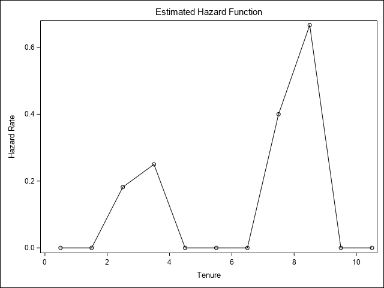

| Summary of the Number of Censored and Uncensored Values Total | Summary of the Number of Censored and Uncensored Values Failed | Summary of the Number of Censored and Uncensored Values Censored | Summary of the Number of Censored and Uncensored Values Percent Censored |
| --- | --- | --- | --- |
| 6 | 4 | 2 | 33.33 |

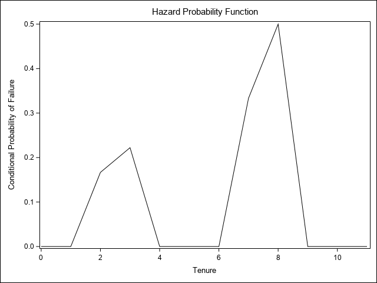

Not surprisingly we see two spikes in the hazard plots - either rate or probability. These spikes correspond to the exact same points where the survival function decreases. This is not surprising since the hazard is the rate of event occurring over time while the survival funciton informs us the proportion of events that haven’t experienced the event over time.

We can easily create the cumulative hazard probability curve as well by aggregrating the hazard probabilities as shown in the DATA step below.

```
ods select html HazardPlot;
proc lifetest data = Simple method = life width = 1 plots=hazard;
    time tenure*censored(1);
    ods output LifetableEstimates = condprob;
run;

data condprob;
    set condprob;
    retain cum_sum;
    cum_sum + condprobfail;
run;

proc sgplot data = condprob;
  styleattrs datacolors=(darkblue darkred) datacontrastcolors=(darkblue darkred);
    series x = lowertime y = cum_sum;
    xaxis label='Tenure';
    yaxis label='Cumulative Hazard Probability';
    title 'Cumulative Hazard Probability Function';
run;
quit;
```

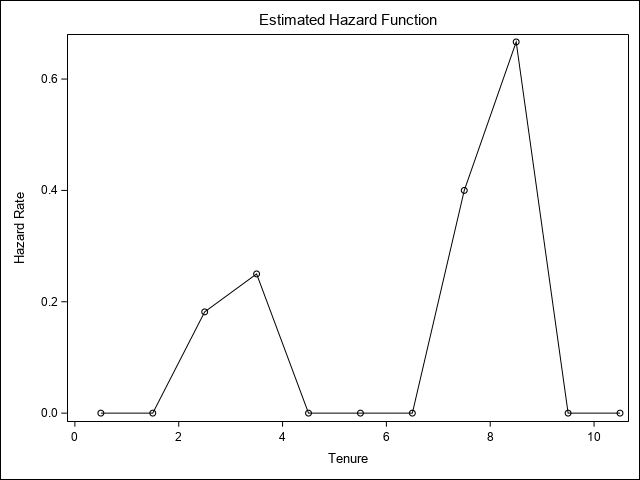

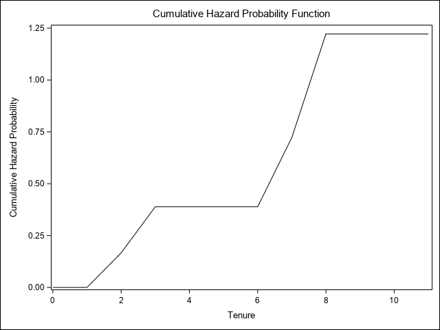

Let’s view these same graphs for our prisoner recidivism data set.

```
ods select html HazardPlot;
proc lifetest data = Survival.Recid method = life width = 1 plots=hazard;
    time week*arrest(0);
    ods output LifetableEstimates = condprob;
run;

data condprob;
    set condprob;
    retain cum_sum;
    cum_sum + condprobfail;
run;

proc sgplot data = condprob;
    series x = lowertime y = condprobfail;
    xaxis label='Week';
    title 'Hazard Probability Function';
run;
quit;

proc sgplot data = condprob;
    series x = lowertime y = cum_sum;
    xaxis label='Week';
    yaxis label='Cumulative Hazard Probability';
    title 'Cumulative Hazard Probability Function';
run;
quit;
```

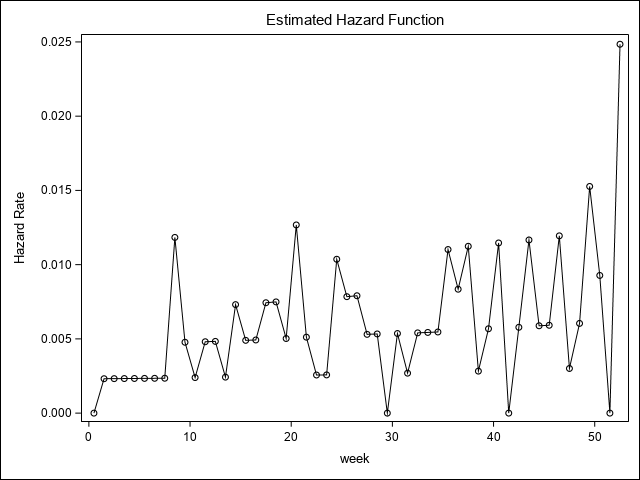

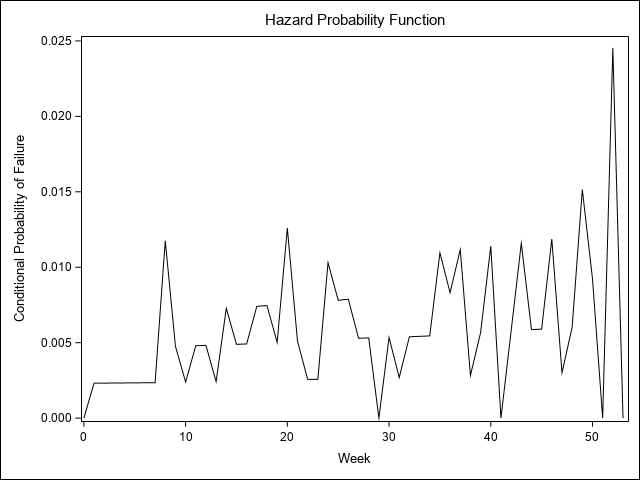

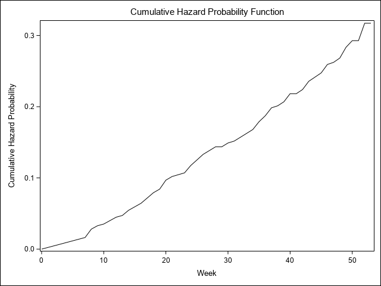

Although the hazard plots appear more volatile, the cumulative hazard shows a rather steady growth, which should be expected by the steady decline of the survival function.

### R

R doesn’t have the same ease of functionality to calculate the hazard function. We can sue the output from the `survfit` function to obtain the hazard probabilities rather easily. Since the hazard probability is just the rate of events to at risk observations for each time point we can calculate this by hand. For our simple data set (the one with customers A through F), we will calculate this for every time point.

```r
summary(simple_km)
```

```
Call: survfit(formula = recid_simple ~ 1, data = simple)

 time n.risk n.event survival std.err lower 95% CI upper 95% CI
    2      6       1    0.833   0.152       0.5827            1
    3      5       1    0.667   0.192       0.3786            1
    7      3       1    0.444   0.222       0.1668            1
    8      2       1    0.222   0.192       0.0407            1
```

```r
simple_km$hp <- simple_km$n.event/simple_km$n.risk
print(simple_km$hp)
```

```
[1] 0.1666667 0.2000000 0.3333333 0.5000000 0.0000000
```

This unfortunately only gives us hazard probabilities at the points where the survival curve dropped which skips where the hazard might take a value of zero. The following code fills in those blanks to better represent the hazard function in totality.

```r
simple_haz <- merge(data.frame(time = seq(1,10,1)), data.frame(time = simple_km$time, hp = simple_km$hp), by = "time", all = TRUE)
simple_haz[is.na(simple_haz) == TRUE] <- 0
print(simple_haz)
```

```
   time        hp
1     1 0.0000000
2     2 0.1666667
3     3 0.2000000
4     4 0.0000000
5     5 0.0000000
6     6 0.0000000
7     7 0.3333333
8     8 0.5000000
9     9 0.0000000
10   10 0.0000000
```

The following statements then plot the hazard probabilities. R does have the cumulative hazard plot built into the `ggsurvplot` function with the `fun = "cumhaz"` option.

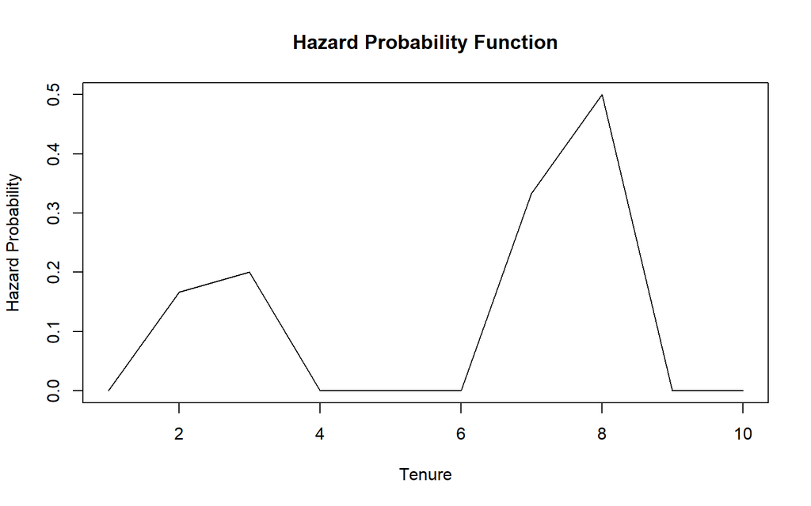

```r
plot(y = simple_haz$hp, x = simple_haz$time, main = "Hazard Probability Function", xlab = "Tenure", ylab = "Hazard Probability",
     type = 'l')
```

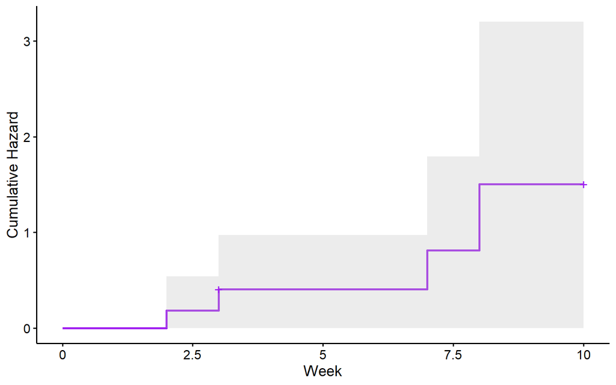

```r
ggsurvplot(simple_km, data = simple, fun = "cumhaz", conf.int = TRUE, palette = "purple",
           xlab = "Week", ylab = "Cumulative Hazard", legend = "none")
```

Let’s view these same graphs for our prisoner recidivism data set.

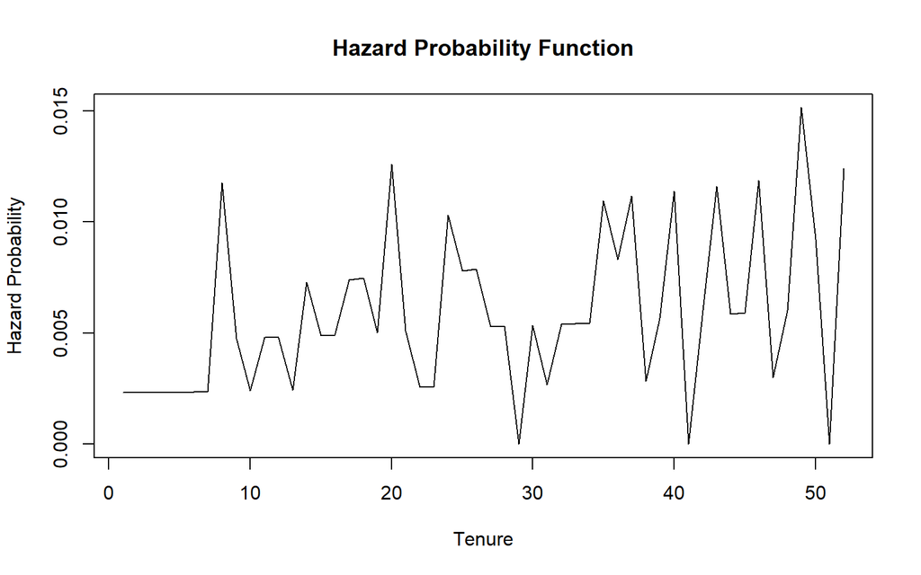

```r
recid_km$hp <- recid_km$n.event/recid_km$n.risk
recid_haz <- merge(data.frame(time = seq(1,52,1)), data.frame(time = recid_km$time, hp = recid_km$hp), by = "time", all = TRUE)
recid_haz[is.na(recid_haz) == TRUE] <- 0

plot(y = recid_haz$hp, x = recid_haz$time, main = "Hazard Probability Function", xlab = "Tenure", ylab = "Hazard Probability",
     type = 'l')
```

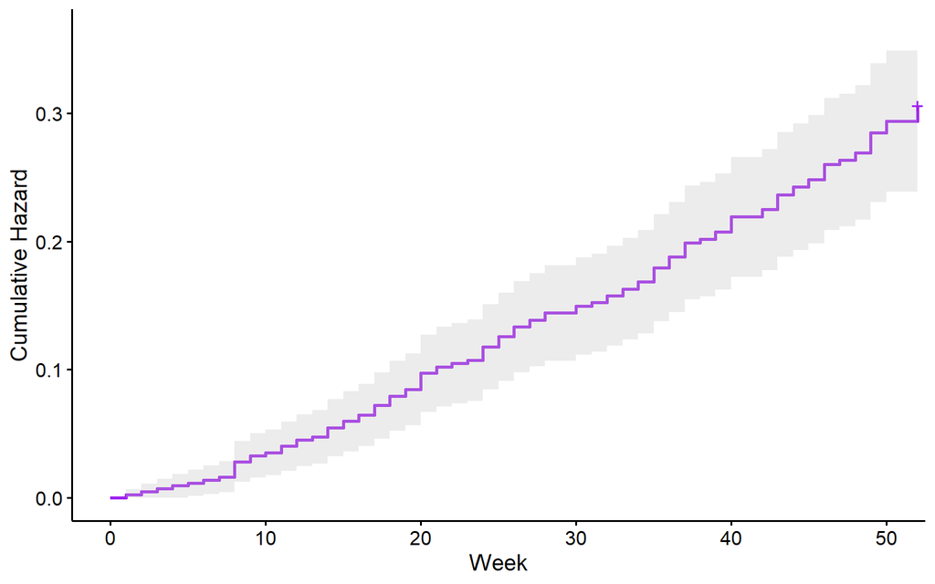

```r
ggsurvplot(recid_km, data = recid, fun = "cumhaz", conf.int = TRUE, palette = "purple",
           xlab = "Week", ylab = "Cumulative Hazard", legend = "none")
```

Although the hazard plots appear more volatile, the cumulative hazard shows a rather steady growth, which should be expected by the steady decline of the survival function.

# Accelerated Failure Time (AFT) Model

Although the Kaplan-Meier approaches to calculating and comparing survival curves is helpful, it doesn’t fully account for the complexities that an actual model to predict tenure would provide. One popular class of models in survival analysis is the **accelerated failure time (AFT) model**.

## Model Structure

The AFT model is a regression that related the independent variables (sometimes called covariates in survival analysis) to the event time $T$. The AFT model is a parametric model - it depends on knowledge of the underlying distribution of the data. It takes the following form:

$$T_i = e^{\beta_0 + \beta_1 x_{i,1} + \cdots + \beta_k x_{i,k} + \sigma \varepsilon_i}$$
This model is obviously non-linear in the relationship between the predictor variables and our target. By taking the natural log of both sides of the equation, we get the following model:

$$\log T_i = \beta_0 + \beta_1 x_{i,1} + \cdots + \beta_k x_{i,k} + \sigma \varepsilon_i$$
Taking the natural log of tenure ensures that the predictions for tenure will always be positive. We would never want to predict a negative time until an event! The predictor variables are being related to the tenure of an event. Here $\sigma$ represents the standard deviation of the errors, $\varepsilon_i$, of our model.

Just as in linear regression, we have assumptions around the errors in our AFT model. The errors in the AFT model can follow *many* different distributions, but we still assume that they have a constant mean, constant variance, and are independent across observations. Due to censoring in survival analysis data sets, we use maximum likelihood estimation to obtain the estimates of the coefficients (the $\beta$’s) in our model instead of ordinary least squares.

Let’s see how to produce these in each of our softwares!

### SAS

In SAS, we use PROC LIFEREG to obtain results for an AFT model. The structure of this procedure is similar to the PROC LIFETEST we saw in the previous section. The `model` statement defines our equation. The target variable is still specified in two pieces - the tenure and whether the event occurred (censoring) - just as in PROC LIFETEST. Here we can also specify predictor variables in the right hand side of the equal sign. There is a `class` statement to specify and create categorical variables as well. Since all of our categorical variables are binary and have already been reference coded, we do not need to use the `class` statement here. The `dist =` option specifies the distribution you assume your errors are following. We will discuss more in later sections on how to test which distribution might be the best one. The `ods html select` options are used to only display certain pieces of the output.

```
ods select html FitStatistics ConvergenceStatus Type3Analysis ParameterEstimates;
proc lifereg data=Survival.Recid;
    model week*arrest(0) = fin age race wexp mar paro prio / dist=lnormal;
run;
```

| Fit Statistics |  |
| --- | --- |
| -2 Log Likelihood | 645.389 |
| AIC (smaller is better) | 663.389 |
| AICC (smaller is better) | 663.816 |
| BIC (smaller is better) | 700.005 |

| Algorithm converged. |
| --- |

| Type III Analysis of Effects Effect | Type III Analysis of Effects DF | Type III Analysis of Effects Wald Chi-Square | Type III Analysis of Effects Pr > ChiSq |
| --- | --- | --- | --- |
| fin | 1 | 4.3657 | 0.0367 |
| age | 1 | 2.9806 | 0.0843 |
| race | 1 | 1.8824 | 0.1701 |
| wexp | 1 | 2.2466 | 0.1339 |
| mar | 1 | 2.4328 | 0.1188 |
| paro | 1 | 0.1092 | 0.7411 |
| prio | 1 | 5.8489 | 0.0156 |

| Analysis of Maximum Likelihood Parameter Estimates Parameter | Analysis of Maximum Likelihood Parameter Estimates DF | Analysis of Maximum Likelihood Parameter Estimates Estimate | Analysis of Maximum Likelihood Parameter Estimates Standard Error | Analysis of Maximum Likelihood Parameter Estimates 95% Confidence Limits | Analysis of Maximum Likelihood Parameter Estimates 95% Confidence Limits | Analysis of Maximum Likelihood Parameter Estimates Chi-Square | Analysis of Maximum Likelihood Parameter Estimates Pr > ChiSq |
| --- | --- | --- | --- | --- | --- | --- | --- |
| Intercept | 1 | 4.2677 | 0.4617 | 3.3628 | 5.1726 | 85.44 | <.0001 |
| fin | 1 | 0.3428 | 0.1641 | 0.0212 | 0.6645 | 4.37 | 0.0367 |
| age | 1 | 0.0272 | 0.0158 | -0.0037 | 0.0581 | 2.98 | 0.0843 |
| race | 1 | -0.3632 | 0.2647 | -0.8819 | 0.1556 | 1.88 | 0.1701 |
| wexp | 1 | 0.2681 | 0.1789 | -0.0825 | 0.6187 | 2.25 | 0.1339 |
| mar | 1 | 0.4604 | 0.2951 | -0.1181 | 1.0388 | 2.43 | 0.1188 |
| paro | 1 | 0.0559 | 0.1691 | -0.2756 | 0.3873 | 0.11 | 0.7411 |
| prio | 1 | -0.0655 | 0.0271 | -0.1186 | -0.0124 | 5.85 | 0.0156 |
| Scale | 1 | 1.2946 | 0.0990 | 1.1145 | 1.5038 |  |  |

First, we can see that SAS reports some common fit statistics for our model - the -2 log likelihood value, AIC, AICC, and BIC. These are only comparison metrics. There is no true metric that defines if these are good or bad because it is relative to the data set that you have. Once we build other models, we can then compare. We also noticed that the algorithm to estimate the model converged. This is very important to have otherwise our results are not reliable.

Next, we have the analysis of the variables themselves. SAS reports the Type 3 analysis of effects. These give you the overall significance of the variables in the model. Due to the model not having any categorical variables with more than 2 levels, the p-value results will not differ from the parameter estimates table below. We will talk about variable selection in a later section, but we can see that we can easily trim our model of some insignificant variables. The parameter estimates table provides us the actual estimates for the AFT model equation. Along with the variable parameter estimates, we also have an estimate for the intercept for the model (at the top of the table) and an estimate for the standard deviation of the errors in our model (at the bottom of the table) - called `Scale`.

### R

In R, we use `survreg` function to obtain results for an AFT model. The structure of this procedure is similar to the `survfit` function we saw in the previous section. The first input defines our equation through a formula. The target variable is still specified in two pieces - the tenure and whether the event occurred (censoring) through the `Surv` object - just as in the `survfit` function. Here we can also specify predictor variables in the right hand side of the ~ symbol. You can use the `factor` function on any variable to specify and create categorical variables as well. Since all of our categorical variables are binary and have already been reference coded, we do not need to use `factor` function here. The `dist =` option specifies the distribution you assume your errors are following. We will discuss more in later sections on how to test which distribution might be the best one. The `summary` funtion is used to display the output.

```r
recid.aft.ln <- survreg(Surv(week, arrest == 1) ~ fin + age + race + wexp + mar + paro + prio, data = recid, dist = 'lognormal')
summary(recid.aft.ln)
```

```
Call:
survreg(formula = Surv(week, arrest == 1) ~ fin + age + race +
    wexp + mar + paro + prio, data = recid, dist = "lognormal")
              Value Std. Error     z       p
(Intercept)  4.2677     0.4617  9.24 < 2e-16
fin          0.3428     0.1641  2.09 0.03667
age          0.0272     0.0158  1.73 0.08427
race        -0.3632     0.2647 -1.37 0.17006
wexp         0.2681     0.1789  1.50 0.13391
mar          0.4604     0.2951  1.56 0.11882
paro         0.0559     0.1691  0.33 0.74108
prio        -0.0655     0.0271 -2.42 0.01559
Log(scale)   0.2582     0.0764  3.38 0.00073

Scale= 1.29

Log Normal distribution
Loglik(model)= -683.2   Loglik(intercept only)= -697.9
    Chisq= 29.35 on 7 degrees of freedom, p= 0.00012
Number of Newton-Raphson Iterations: 4
n= 432
```

First, we can see that R reports the analysis of the variables themselves. R reports the parameter estimates for each variable. We will talk about variable selection in a later section, but we can see that we can easily trim our model of some insignificant variables. The parameter estimates table provides us the actual estimates for the AFT model equation. Along with the variable parameter estimates, we also have an estimate for the intercept for the model (at the top of the table) and an estimate for the standard deviation of the errors in our model (at the bottom of the table) - called `scale`. R reports both the natural log of the scale as well as the scale itself here.

Next, R performs an overall likelihood ratio test to compare our model to an intercept only model. The null hypothesis here is that the two models are the same - essentially none of the variables in our model are useful. Since the p-value for this test is below any reasonable $\alpha$ level for our data set, we can conclude that at least one of the variables in the data set is helpful to predicting tenure.

## Interpretation

Let’s talk about interpreting the coefficients from the previous section’s output. If a parameter estimate for a variable is *positive* then increases in that variable will *increase* the expected survival time (time until the event). If the parameter estimate is *negative* then increases in that variables will *decrease* the expected survival times. If a parameter estimate is zero (or statistically insignificant) then increases in that variable have *no impact* on the expected survival times.

However, unlike linear regresion, the value of the coefficient isn’t the exact increase in survival time since we look our natural log transformation of the target variable. Instead, we can interpret a transformation of that coefficient. $100\times (e^{\hat{\beta}} - 1)$ is the % increase in the expected survival time for each one-unit increase in the variable. If the variable is categorical instead, $100\times (e^{\hat{\beta}} - 1)$ is the % increase in the expected survival time for that category compared to the reference category.

Let’s see how to produce these in each of our softwares!

### SAS

In SAS we just add the `outest =` option to obtain a data set, here called *betas*, that contains the parameter estimates from our AFT model. From there, a simple DATA STEP will calculate the needed transformation. PROC PRINT then displays the result.

```
proc lifereg data=Survival.Recid outest=betas noprint;
    model week*arrest(0) = fin age mar prio / dist=lnormal;
run;

data betas;
   set betas;
   fin_i = (exp(fin) - 1)*100;
   age_i = (exp(age) - 1)*100;
   mar_i = (exp(mar) - 1)*100;
   prio_i = (exp(prio) - 1)*100;
   keep fin_i age_i mar_i prio_i;
run;

proc print data=betas;
run;
```

| Obs | fin_i | age_i | mar_i | prio_i |
| --- | --- | --- | --- | --- |
| 1 | 39.3574 | 3.38643 | 75.2237 | -7.16307 |

Let’s interpret both a categorical and continuous variable. First, the categorical variable of financial aid. Here we can see that people who were given financial aid have an estimated 39.36% increase in expected time until rearrest, holding all else constant in the model. Next, let’s look at the continuous variable for number of previous convictions. Every additional previous conviction decreases the expected time until rearrest by 7.16%, holding all else constant in the model. These increases are percentage increases at every point in time. Therefore, the actual change in tenure time is different depending on predicted failure time. The survival curves essentially diverge, but are not parallel.

### R

In R we just calculate the needed transformation on the coefficients from our model. These coefficients are obtained from the `coef` function.

```r
(exp(coef(recid.aft.ln))-1)*100
```

```
(Intercept)         fin         age        race        wexp         mar
7035.487765   40.895413    2.757519  -30.452482   30.751980   58.463386
       paro        prio
   5.747012   -6.341735
```

## Model Assumptions

Recall from earlier that AFT models are **parametric** models as we assume failure time has a particular structure and distribution. The Kaplan-Meier estimate makes no assumption on failure time - a **nonparametric** approach. Parametric methods allow for more detailed/precise estimation than nonparametric methods *if* the distribution is specified correctly.

Remember the structure we have for the AFT model:

$$\log T_i = \beta_0 + \beta_1 x_{i,1} + \cdots + \beta_k x_{i,k} + \sigma \varepsilon_i$$
The scale term ($\sigma$) describes the spread of the distribution of the errors. Another common form is the inverse of the scale - called the **rate**: $\lambda = 1/\sigma$. If $\sigma$ is small, then events are not spread out. In other words, events are happening close together and the rate of events ($\lambda$) is large.

## Common Distributions

We will focus on the distribution of failure time $T$ as compared to the error itself since this is the typical input for software to define the distribution of the model. The hardest part is trying to evaluate which distribution is the best distribution. Two common approaches are:

1. Visualization
2. Statistical Tests

You should never really think about these evaluations as which distribution is the “correct” distribution. The following contains commonly used distributions for survival data, but there is **no guarantee** that your data will adequately match just one of the distributions here, or even any of them at all.

First, let’s examine the **exponential distribution**. This is the simplest of all of the distributions we will cover because it has a constant hazard that doesn’t depend on time.

- Survival Function: $S(t) = e^{-\lambda t}$
- Hazard Function: $h(t) = \lambda$

The exponential distribution works great when failures are completely random. For example, a light bulb breaking, electronic failures, etc.

The next distribution is the Weibull distribution. This is the most commonly used distribution in survival analysis. This distribution has two parameters - scale and shape and is defined as follows:

- Survival Function: $S(t) = e^{-(\lambda t)^\gamma}$
- Hazard Function: $h(t) = \lambda \gamma (\lambda t)^{\gamma - 1}$

The shape parameter, $\gamma$, determines whether the hazard increases or decreases with time. If $\gamma > 1$ then the hazard increases with time. For example, aging parts on a var wear out over time. If $\gamma < 1$ then the hazard decreases with time. For example, post-surgery complications happen fewer and fewer the further from the surgery date. Notice that the hazard for the Weibull distribution is constant when $\gamma = 1$ - the exponential distribution! The exponential distribution is a special case of the Weibull distribution. All of our softwares test this automatically when running AFT models. R uses a hypothesis test to see if the natural log of the scale term equals 0. Scale here is defined as $1/\gamma$ so the natural log of this would be 0 if $\gamma = 1$. SAS uses the Lagrange multuiplier test for scale to directly test if $\gamma = 1$ instead. Be careful when looking at output from either SAS or R with regards to the naming conventions of the parameters. The naming convention in a distributional sense for the Weibull is rate ($\lambda$) and shape ($\gamma$). However, in an AFT model, the parameterizations change around. Refer to the table below for details:

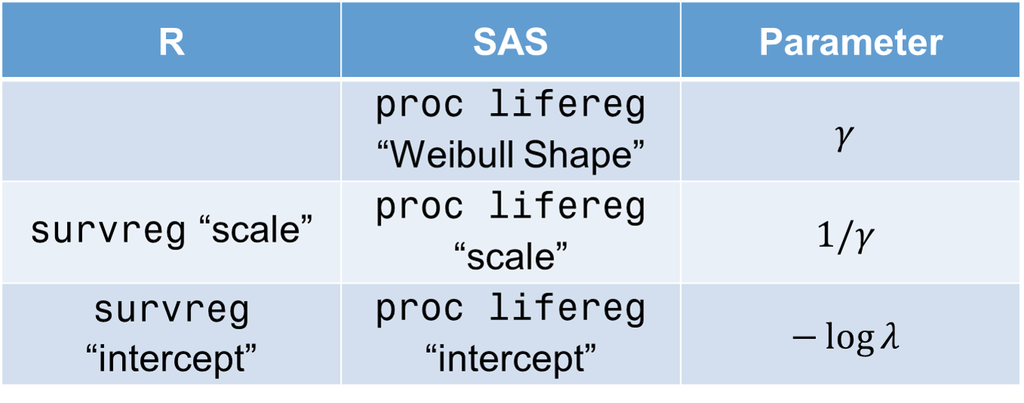

Weibull Parameterizations

Another common distribution is the log-normal distribution. If $T$ has a log-normal distribution, then the errors, $\varepsilon$, follow a normal distribution. If there is no censoring, an AFT model with a log-normal tenure distribution is the same as a linear regression with $y = \log(T)$.

All of the above distributions are part of a family of distributions called the Gamma family of distributions. The generalized gamma distribution has all of the above distributions as special cases.

The log-logistic distribution is another common distribution. This distribution allows the hazard to increase and then decrease if its shape parameter $\gamma > 1$. The log-logistic AFT model is just an ordinal logistic regression model.

The generalized F distribution actually contains all of the gamma family of distributions as well as the log-logistic distribution as special cases as well. The following chart represents how all these distributions are nested within each other in some form.

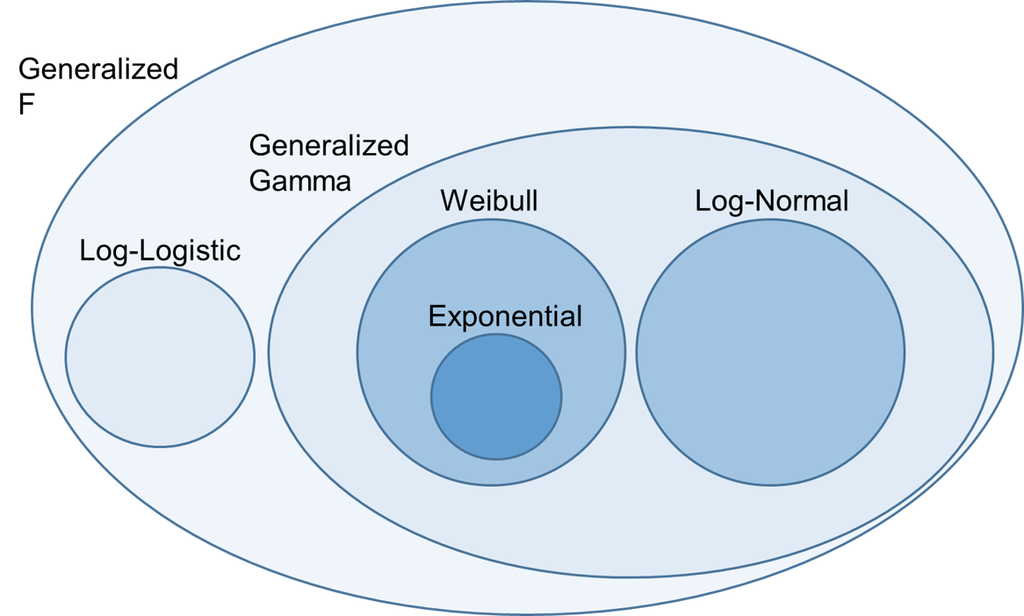

Nested Distributions

The relationships between all these distributions underly the visualization and statistical tests for comparing the distributions to find the best one.

### Visual Comparisons

The first approach to finding the best distribution out of the collection is through visualizations.We take the known equations for each of the distributions and compare our data to the theoretical distribution we are fitting.

Let’s take a look at how to do this in each of our softwares!

#### SAS

SAS uses probability plots to help visualize the distributions. To change what distribution you are fitting to the AFT model you just change the name in the `dist =` option. SAS will provide a probability plot to compare your data to the theoretical distribution with the `probplot` statement. If our data fits the distribution well, we should see it follow a relatively straight diagonal line. The theoretical diagonal line as well as its confidence interval is plotted for us to compare with. The `alpha =` option helps define the confidence interval. Let’s compare our prisoner recidivism data set AFT model to the exponential distribution. Note that all of the variables in the model. Since we are unsure of the distribution, we cannot trust the statistical tests on the variables. It is best to perform this piece with all the variables present.

```
ods html select ProbPlot;
proc lifereg data=Survival.Recid;
     model Week*arrest(0) = fin age race wexp mar paro prio / alpha=0.015 dist=exponential;
   probplot;
run;
```

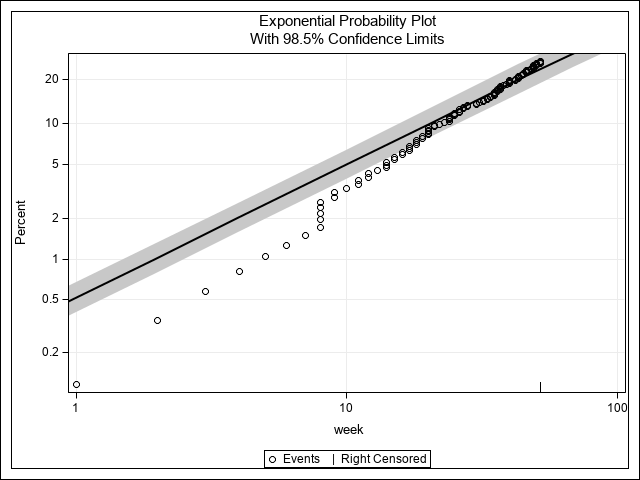

Based on the above plot, it appears that our data doesn’t follow an exponential distribution because it goes outside of the confidence interval bounds for a large portion of our plot. Let’s compare it to the other distributions.

```
ods html select ProbPlot;
proc lifereg data=Survival.Recid;
     model Week*arrest(0) = fin age race wexp mar paro prio / alpha=0.015 dist=weibull;
     probplot;
run;

ods html select ProbPlot;
proc lifereg data=Survival.Recid;
     model Week*arrest(0) = fin age race wexp mar paro prio / alpha=0.015 dist=gamma;
     probplot;
run;

ods html select ProbPlot;
proc lifereg data=Survival.Recid;
     model Week*arrest(0) = fin age race wexp mar paro prio / alpha=0.015 dist=llogistic;
     probplot;
run;
```

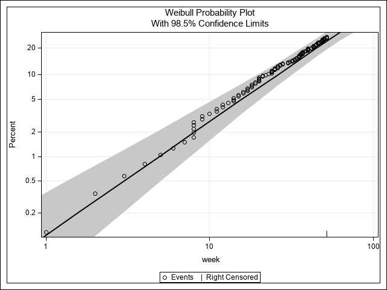

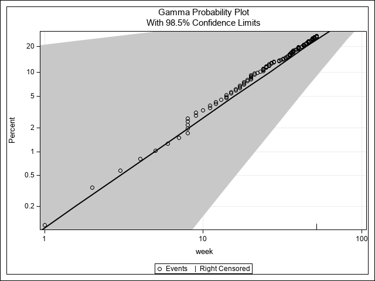

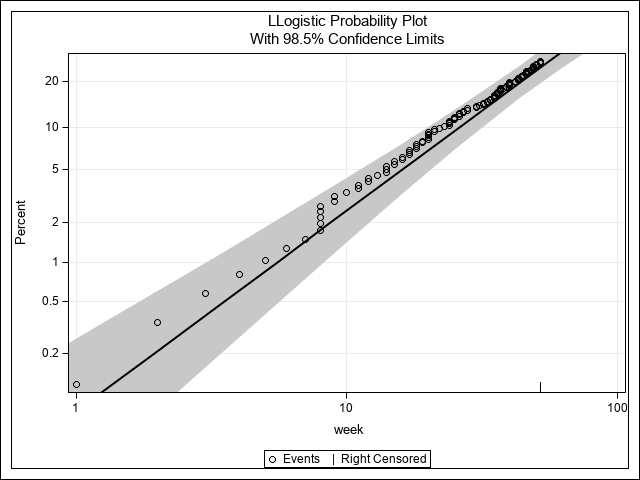

It appears that the data might follow the Weibull distribution since the entire set of points is contained inside of the confidence intervals. Of course, if it follows a Weibull, then it would also follow a gamma distribution since the Weibull is a special case. Obviously, if choosing between the Weibull and gamma we would always choose the simpler model if both are equally valid. However, it also appears as if the data might follow a log-logistic distribution as well. This is where things become difficult with the visualizations. The log-logistic is NOT a special case of the Weibull so those cannot be directly compared. In fact, the log-logistic isn’t even a special case of the gamma distribution. Statistical tests might be of some more help.

#### R

R uses cumulative hazard plots to help visualize the distributions. To utilize these plots we need a different modeling function to model the AFT model - the `flexsurvreg` function. The structure of this function is the same as the `survreg` function. To change what distribution you are fitting to the AFT model you just change the name in the `dist =` option. R will provide a probability plot to compare your data to the theoretical cumulative hazard distribution with the `plot` function on this `flexsurvreg` object. If our data fits the distribution well, we should see it follow the theoretical cumulative hazard line as well as stay in its confidence interval. Let’s compare our prisoner recidivism data set AFT model to the exponential distribution. Note that all of the variables in the model. Since we are unsure of the distribution, we cannot trust the statistical tests on the variables. It is best to perform this piece with all the variables present.

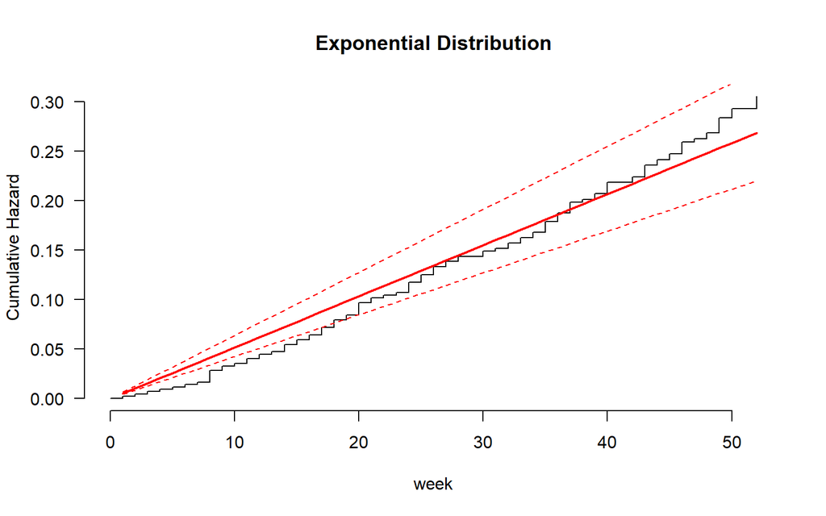

```r
recid.aft.e <- flexsurvreg(Surv(week, arrest == 1) ~ fin + age + race + wexp + mar + paro + prio, data = recid, dist = "exp")

plot(recid.aft.e, type = "cumhaz", ci = TRUE, conf.int = FALSE, las = 1, bty = "n",
     xlab = "week", ylab = "Cumulative Hazard", main = "Exponential Distribution")
```

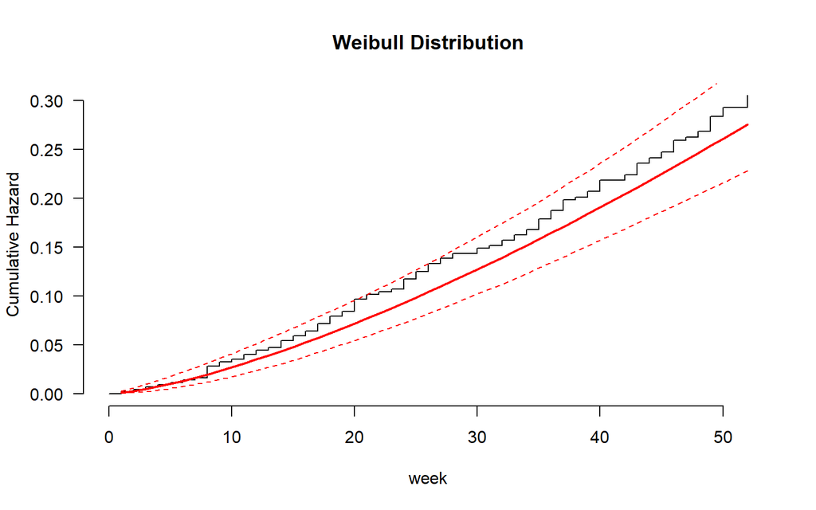

```r
recid.aft.w <- flexsurvreg(Surv(week, arrest == 1) ~ fin + age + race + wexp + mar + paro + prio, data = recid, dist = "weibull")

plot(recid.aft.w, type = "cumhaz", ci = TRUE, conf.int = FALSE, las = 1, bty = "n",
     xlab = "week", ylab = "Cumulative Hazard", main = "Weibull Distribution")
```

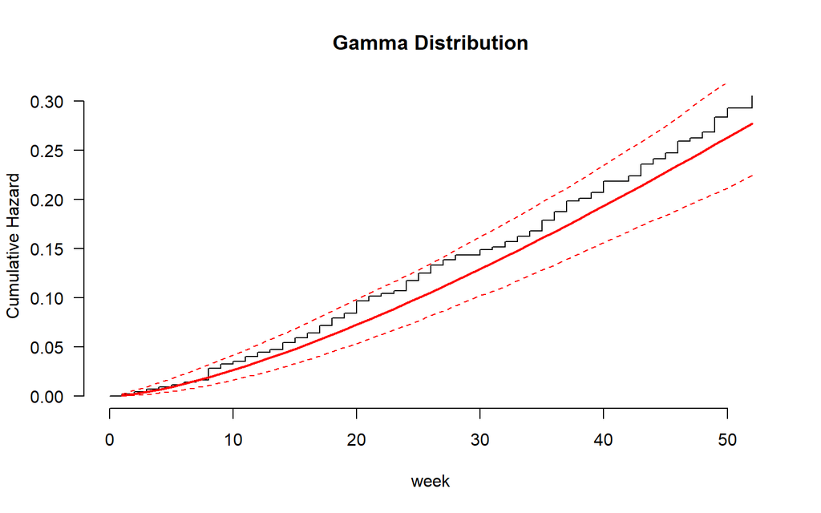

```r
recid.aft.g <- flexsurvreg(Surv(week, arrest == 1) ~ fin + age + race + wexp + mar + paro + prio, data = recid, dist = "gamma")

plot(recid.aft.g, type = "cumhaz", ci = TRUE, conf.int = FALSE, las = 1, bty = "n",
     xlab = "week", ylab = "Cumulative Hazard", main = "Gamma Distribution")
```

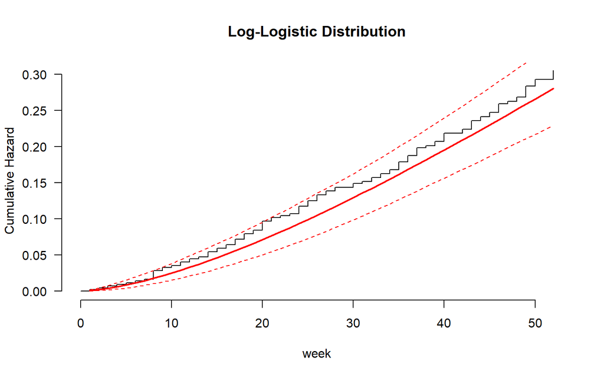

```r
recid.aft.ll <- flexsurvreg(Surv(week, arrest == 1) ~ fin + age + race + wexp + mar + paro + prio, data = recid, dist = "llogis")

plot(recid.aft.ll, type = "cumhaz", ci = TRUE, conf.int = FALSE, las = 1, bty = "n",
     xlab = "week", ylab = "Cumulative Hazard", main = "Log-Logistic Distribution")
```

It appears that the data might follow the Weibull distribution since the entire set of points is contained inside of the confidence intervals. Of course, if it follows a Weibull, then it would also follow a gamma distribution since the Weibull is a special case. Obviously, if choosing between the Weibull and gamma we would always choose the simpler model if both are equally valid. However, it also appears as if the data might follow a log-logistic distribution as well. You coudl make the case that it appears that one or two points on the line fall just outside the confidence intervals for the log-logistic plot. This is where things become difficult with the visualizations. The log-logistic is NOT a special case of the Weibull so those cannot be directly compared. In fact, the log-logistic isn’t even a special case of the gamma distribution. Statistical tests might be of some more help.

### Goodness-of-Fit Tests

Luckily, most of the distributions we went over earlier are nested versions of each other in some way. That means we can use statistical tests that compare nested models to compare these models and the underlying distributions. We will use the likelihood ratio test since these models are all estimated with MLE. The likelihood ratio test assumes two models (one being nested within the other) are the same. If the two models are statistically different, then the larger (more complex) of the two is finding more information. If they are the same statistically, then the complexity of the larger model provides no additional benefit and we go with the simpler model. The test statistic is the following:

$$LRT = -2(\log(L_{nested}) - \log(L_{full})))$$
Again, just as with the plotting, we use the full model since we cannot rely on the statistical tests of the model with an incorrect distribution. The following table provides the log-likelihood value obtained from the softwares for each model.

Likelihood Values from AFT Models

| Log-Likelihood Value | Implied Distribution | Software |
| --- | --- | --- |
| -686.37 | Exponential | SAS/R |
| -679.92 | Weibull | SAS/R |
| -683.23 | Log-Normal | SAS/R |
| -679.92 | Generalized Gamma | SAS/R |
| -679.94 | Log-Logistic | SAS/R |
| -678.72 | Generalized F | R |

Let’s use each of our softwares to compare these models through the LRT!

#### SAS

With SAS we can easily perform the LRT through the DATA step. Here we can just run the calculation directly. After inputting the log-likelihood values from the unlogged target variable piece of the fit statistics from SAS we can then directly calculate the LRT for any nested comparison. Here we are comparing the exponential to the generalized gamma, the Weibull to the generalized gamma, and the log-normal to the generalized gamma. The degrees of freedom on these tests are just the difference in the number of parameters between the distributions since all the mdoels have the same number of variables. For example, The exponential has only one parameter to estimate, but the generalized gamma has three. Therefore, the degrees of freedom would be 2. Early in the code above, we saw that the Weibull is the statistical choice if choosing between it and the exponential.

```
data GOF;
    Exp = -686.37;
  Weib = -679.92;
  LNorm = -683.23;
  GGam = -679.92;

    LRT1 = -2*(Exp - GGam);
    LRT2 = -2*(Weib - GGam);
    LRT3 = -2*(LNorm - GGam);

    P_Value1 = 1 - probchi(LRT1,2);
    P_Value2 = 1 - probchi(LRT2,1);
    P_Value3 = 1 - probchi(LRT3,1);
run;

proc print data=GOF;
    var LRT1-LRT3 P_Value1-P_Value3;
run;
```

| Obs | LRT1 | LRT2 | LRT3 | P_Value1 | P_Value2 | P_Value3 |
| --- | --- | --- | --- | --- | --- | --- |
| 1 | 12.9 | 0 | 6.62 | .001580522 | 1 | 0.010084 |

After printing our results with PROC PRINT, we can see the comparisons. Remember, the null hypothesis is that the two models are equal. If this is the case we will go with the simpler model. However, if this isn’t the case, we need to go with the more complicated model since it performs better. Based on these results, the gamma distribution outperforms both the log-normal and the exponential. However, it doesn’t outperform the Weibull distribution. From these three tests, it appears that the Weibull distribution is the best choice. This does NOT mean that our data fits the Weibull distribution necessarily. It is just saying that the Weibull is the best distribution among the choices we have tested.

#### R

With R we can easily perform the LRT. Here we can just run the calculation directly. We can extract the log-likelihood value directly from our model objects and store them as separate objects. We can then directly calculate the LRT for any nested comparison. Here we are comparing the exponential to the generalized gamma, the Weibull to the generalized gamma, the log-normal to the generalized gamma, the generalized gamma to the generalized F, and the log-logistic to the generalized F. The degrees of freedom on these tests are just the difference in the number of parameters between the distributions since all the mdoels have the same number of variables. For example, The exponential has only one parameter to estimate, but the generalized gamma has three. Therefore, the degrees of freedom would be 2. Early in the code above, we saw that the Weibull is the statistical choice if choosing between it and the exponential.

```r
like.e <- flexsurvreg(Surv(week, arrest == 1) ~ fin + age + race + wexp + mar + paro + prio, data = recid, dist = "exp")$loglik
like.w <- flexsurvreg(Surv(week, arrest == 1) ~ fin + age + race + wexp + mar + paro + prio, data = recid, dist = "weibull")$loglik
like.ln <- flexsurvreg(Surv(week, arrest == 1) ~ fin + age + race + wexp + mar + paro + prio, data = recid, dist = "lnorm")$loglik
like.g <- flexsurvreg(Surv(week, arrest == 1) ~ fin + age + race + wexp + mar + paro + prio, data = recid, dist = "gamma")$loglik
like.ll <- flexsurvreg(Surv(week, arrest == 1) ~ fin + age + race + wexp + mar + paro + prio, data = recid, dist = "llogis")$loglik
like.f <- flexsurvreg(Surv(week, arrest == 1) ~ fin + age + race + wexp + mar + paro + prio, data = recid, dist = "genf")$loglik

pval.e.g <- 1 - pchisq((-2*(like.e-like.g)), 2)
pval.w.g <- 1 - pchisq((-2*(like.w-like.g)), 1)
pval.ln.g <- 1 - pchisq((-2*(like.ln-like.g)), 1)
pval.g.f <- 1 - pchisq((-2*(like.g-like.f)), 1)
pval.ll.f <- 1 - pchisq((-2*(like.ll-like.f)), 1)

Tests <- c('Exp vs. Gam', 'Wei vs. Gam', 'LogN vs. Gam', 'Gam vs. F', 'LogL vs. F')
P_values <- c(pval.e.g, pval.w.g, pval.ln.g, pval.g.f, pval.ll.f)
cbind(Tests, P_values)
```

```
     Tests          P_values
[1,] "Exp vs. Gam"  "0.00172559564523367"
[2,] "Wei vs. Gam"  "1"
[3,] "LogN vs. Gam" "0.0110221983305441"
[4,] "Gam vs. F"    "0.108860911475402"
[5,] "LogL vs. F"   "0.118276422245853"
```

After combining our results with a couple extra lines of code, we can see the comparisons. Remember, the null hypothesis is that the two models are equal. If this is the case we will go with the simpler model. However, if this isn’t the case, we need to go with the more complicated model since it performs better. Based on these results, the gamma distribution outperforms both the log-normal and the exponential. However, it doesn’t outperform the Weibull distribution. We can see that the F distribution does not outperform either of the gamma or log-logistic. From these tests, it appears that the Weibull distribution or the log-logistic distribution are both valid choices. Which to choose? From the visual inspections we leaned towards the Weibull so that is what we will go with. This does NOT mean that our data fits the Weibull distribution necessarily. It is just saying that the Weibull is the best distribution among the choices we have tested.

## Predicting Survival & Event Times

AFT models assume a distribution for $T$, meaning that we expect event times to behave in a certain way. *IF* we assume the correct distribution, we can predict quantiles, survival probabilities, event times, survival curves, and changes in the expected event time as predictor variables change value. Some example predictions are:

- Median survival time: $\hat{S}_i(t) = 0.5$
- Time which $q$% of people with the same predictor values have the event: $\hat{S}_i(t) = 1-q$
- The 20 week survival probability: $\hat{S}_i(20)$

Careful though! The predictions of $\hat{S}_i(t)$ completely depend on the distribution used so predictions will NOT be the same across different distributions. This is why it is important to pick the best distribution we can.

Let’s see how to get these predictions in our different softwares!

### SAS

Let’s first look at the quantiles from our survival probability predictions. For each observation in our data set we can estimate any quantile on their observation specific survival curve. We can easily do this in SAS using the `output` statement in PROC LIFEREG. We build our model as previously described using the Weibull distribution (based on our distribution results above). In the `output` statement we use the `out =` option to define the data set where these will be stored, the `p =` option to define the name of our predictions column in the data set, the `std_err =` option to define the name of the standard errors column, and the `quantile =` option to define the quantiles we want to estimate for each observation. Here we ask for the quartiles. We then only print out the first 9 observations (quartiles for the first 3 observations) in our data set.

```
proc lifereg data=Survival.Recid noprint;
    model Week*arrest(0) = fin age prio / dist=weibull;
    output out=recid_q p=quan quantile=(0.25, 0.50, 0.75) std_err=se;
run;

proc print data=recid_q (obs = 9);
    var week _PROB_ quan se;
run;
```

| Obs | week | *PROB* | quan | se |
| --- | --- | --- | --- | --- |
| 1 | 20 | 0.25 | 52.688 | 5.8237 |
| 2 | 20 | 0.50 | 98.728 | 12.5176 |
| 3 | 20 | 0.75 | 161.958 | 24.8511 |
| 4 | 17 | 0.25 | 24.180 | 3.5528 |
| 5 | 17 | 0.50 | 45.308 | 6.2055 |
| 6 | 17 | 0.75 | 74.325 | 10.7593 |
| 7 | 25 | 0.25 | 17.891 | 3.9174 |
| 8 | 25 | 0.50 | 33.524 | 6.9332 |
| 9 | 25 | 0.75 | 54.994 | 11.4201 |

From the output above we can see that we have the predicted event time for each of our quantiles for each observation. For example, the first observation has a 25% chance of failing before week 52.69, a 50% of failing before week 98.73, and a 75% chance of failing before week 161.96. The same can be seen for subsequent observations.

Next, we can predict an expected change in event time when we change the value of a predictor variable. For this example, we want to predict the new survival time for individuals who were **not** given financial aid **if** they had been given financial aid. To do this, we first need to fit the model and output some results. PROC LIFEREG still has our AFT model built on the Weibull distribution. However, now we ask for different output from the `output` statement. We use the `xbeta =` option to provide the predicted natural log of survival time. We name it *lp* because it is sometimes referred to as the linear portion of the model. We also want the survival probability at the event time in the data set. SAS provides the *failure* probability (the opposite of survival) with the `cdf =` option. We also extract the parameter estimates of our model using the `outest =` option in the PROC LIFEREG statement.

The next piece of code uses a DATA step to create MACRO variables for our shape parameter (defined as the inverse of the scale parameter from the `outest =` data set) and the financial aid variable’s coefficient. The next DATA step subsets our data to just the individuals who were rearrested and who did not receive financial aid (deleting observations who did not meet those requirements). We then calculate the survival probability as the opposite of the failure probability. Next, we calculate the new prediction of the log of survival time by taking the original *lp* variable and adding the effect of the coefficient for the financial aid. Remember, financial aid is just a binary variable, so by adding the coefficient, we are just adding the effect if that observation had been given financial aid. We need to then pinpoint this new prediction on the Weibull distribution. We use the `squantile` function for the Weibull distribution, along with the survival probability of that observation, the shape parameter from our `outest =` data set, and this new prediction of the survival time (remember to take the `exp` function to negate the natural log). Effectively, we are assuming that the individual would be rearrested at the point when their survival probability reached the point they were rearrested in our data set. Our goal here is to extend that survival curve out as much as possible using the financial aid variable.

```
proc lifereg data=Survival.Recid outest=Beta noprint;
    model Week*arrest(0) = fin age prio / dist=weibull;
    output out=recid_e xbeta=lp cdf=cdistfunc;
run;

data _null_;
    set Beta;
    call symput('shape', 1/_SCALE_);
    call symput('beta_fin', fin);
run;

data recid_e;
    set recid_e;
    if arrest = 0 then delete;
    if fin = 1 then delete;
    survprob = 1 - cdistfunc;

    lp_new = lp + &beta_fin;

    newtime = squantile('weibull', survprob, &shape, exp(lp_new));
    diff = newtime - week;
run;

proc print data=recid_e (obs = 3);
    var survprob lp lp_new week newtime diff;
run;
```

| Obs | survprob | lp | lp_new | week | newtime | diff |
| --- | --- | --- | --- | --- | --- | --- |
| 1 | 0.92858 | 4.85409 | 5.10359 | 20 | 25.6678 | 5.66776 |
| 2 | 0.83891 | 4.07520 | 4.32470 | 17 | 21.8176 | 4.81760 |
| 3 | 0.63152 | 3.77398 | 4.02349 | 25 | 32.0847 | 7.08471 |

Here we are looking at the first three observations from our subsetting data set of just individuals who were rearrested and did not originally have financial aid. We can see that the first individual would have had a predicted increase in survival time until rearrest of 5.67 weeks. This approach can be used to measure the impacts of a variety of variables to see which ones might be best used.

### R

Let’s first look at the quantiles from our survival probability predictions. For each observation in our data set we can estimate any quantile on their observation specific survival curve. We can easily do this in R using the `predict` function on our model object. We build our model as previously described using the Weibull distribution (based on our distribution results above). In the `predict` function we use the `type = "quantile"` option to request the quantile predictions, the `se.fit = TRUE =` option to include the standard errors, and the `p =` option to define the quantiles we want to estimate for each observation. Here we ask for the quartiles. We then only print out the first 3 observations (quartiles for the first 3 observations in separate columns) in our data set.

```r
recid.aft.w <- survreg(Surv(week, arrest == 1) ~ fin + age +prio, data = recid, dist = 'weibull')
summary(recid.aft.w)
```

```
Call:
survreg(formula = Surv(week, arrest == 1) ~ fin + age + prio,
    data = recid, dist = "weibull")
              Value Std. Error     z       p
(Intercept)  3.7738     0.3581 10.54 < 2e-16
fin          0.2495     0.1372  1.82 0.06901
age          0.0478     0.0154  3.11 0.00189
prio        -0.0698     0.0201 -3.47 0.00051
Log(scale)  -0.3367     0.0892 -3.77 0.00016

Scale= 0.714

Weibull distribution
Loglik(model)= -682   Loglik(intercept only)= -696.6
    Chisq= 29.17 on 3 degrees of freedom, p= 2.1e-06
Number of Newton-Raphson Iterations: 6
n= 432
```

```r
survprob.75.50.25 <- predict(recid.aft.w, type = "quantile", se.fit = TRUE,
                             p = c(0.25, 0.5, 0.75))
head(survprob.75.50.25$fit, n = 3)
```

```
         [,1]     [,2]      [,3]
[1,] 52.68849 98.72758 161.95827
[2,] 24.17956 45.30760  74.32514
[3,] 17.89085 33.52383  54.99438
```

From the output above we can see that we have the predicted event time for each of our quantiles for each observation. For example, the first observation has a 25% chance of failing before week 52.69, a 50% of failing before week 98.73, and a 75% chance of failing before week 161.96. The same can be seen for subsequent observations.

In fact, the predict function offers great options for predicting survival times from an AFT model. Instead of the median, we could also calculate the average survival time for each observation. Again, we are using the assumption of the distribution being correctly specified to allow us to predict the mean. To do this, we just change the to the `type = "response"` option to obtain the average event time for each observation. The first three are printed below.

```r
p.time.mean <- predict(recid.aft.w, type = "response", se.fit = TRUE)
head(p.time.mean$fit, n = 3)
```

```
[1] 128.26394  58.86229  43.55317
```

From the output above we see that the first observation has an average predicted event time of 128.26 weeks for the event to occur.

Using a new function, the `psurvreg` function, in conjunction with the `predict` function, we can obtain estimated survival probabilities at any time point. The `psurvreg` function has four main inputs. The first input is the time point of interest. In the first piece of code we use the actual week of survival for each individual. The second piece of code specifies the time point of 10 to obtain the survival probability for each individual at week 10. The next three options are the `mean =` option to specify the predicted natural log of event time from the `predict` function with `type = "lp"` (it is named *lp* because it is sometimes referred to as the linear portion of the model), the `scale =` option to specify the predicted scale of the distribution from the model object, and the `dist =` option to specify the distribution from the AFT model that was assumed.

```r
survprob.actual <- 1 - psurvreg(recid$week,
                                mean = predict(recid.aft.w, type = "lp"),
                                scale = recid.aft.w$scale,
                                distribution = recid.aft.w$dist)
head(survprob.actual, n = 3)
```

```
[1] 0.9285822 0.8389085 0.6315234
```

```r
survprob.10wk <- 1 - psurvreg(10,
                              mean = predict(recid.aft.w, type = "lp"),
                              scale = recid.aft.w$scale,
                              distribution = recid.aft.w$dist)
head(survprob.10wk, n = 3)
```

```
[1] 0.9723202 0.9198457 0.8803901
```

From the above output we can see the first observation had a survival probability of 0.929 when they were arrested and a survival probability of 0.972 at week 10.

Lastly, we can predict an expected change in event time when we change the value of a predictor variable. For this example, we want to predict the new survival time for individuals who were **not** given financial aid **if** they had been given financial aid. To do this we just use the `qsurvreg` function. The `qsurvreg` function has four main inputs. The first input is the survival probability of interest. This comes from the above code where we store the survival probability of each observation at the point of the event (or when they were censored). The next three options are the `mean =` option to specify the predicted natural log of event time from the `predict` function with `type = "lp"`, the `scale =` option to specify the predicted scale of the distribution from the model object, and the `dist =` option to specify the distribution from the AFT model that was assumed. The `mean =` option has the calculated new prediction of the log of survival time by taking the original *lp* variable and adding the effect of the coefficient for the financial aid using the `coef` function to obtain it. Remember, financial aid is just a binary variable, so by adding the coefficient, we are just adding the effect if that observation had been given financial aid. Effectively, we are assuming that the individual would be rearrested at the point when their survival probability reached the point they were rearrested in our data set. Our goal here is to extend that survival curve out as much as possible using the financial aid variable. We then just calculate the difference between our original survival time and the newly estimated one.

```r
new_time <-  qsurvreg(1 - survprob.actual,
                      mean = predict(recid.aft.w, type = "lp") + coef(recid.aft.w)['fin'],
                      scale = recid.aft.w$scale,
                      distribution = recid.aft.w$dist)

recid$new_time <- new_time
recid$diff <- recid$new_time - recid$week

head(data.frame(recid$week, recid$new_time, recid$diff), n = 3)
```

```
  recid.week recid.new_time recid.diff
1         20       25.66776   5.667764
2         17       21.81760   4.817600
3         25       32.08471   7.084706
```

Here we are looking at the first three observations. We can see that the first individual would have had a predicted increase in survival time until rearrest of 5.67 weeks. This approach can be used to measure the impacts of a variety of variables to see which ones might be best used.

# Cox Regression

The Accelerated Failure Time model has a big disadvantage - needing to estimate the distribution of our data. With an incorrect distribution, we will get incorrect results. The other big class of models in survival analysis is the Cox regression. These models do not have the distribution assumption of the AFT model. However, that doesn’t mean they don’t have their own disadvantages as well. Let’s learn more about them!

## Proportional Hazards

$$\log h(t) = \log h_0(t) + \beta_1 x_{i,1} + \cdots + \beta_k x_{i,k}$$
In other words, we are predicting the hazard function defined in this way:

$$h(t) = h_0(t)e^{\beta_1 x_{i,1} + \cdots + \beta_k x_{i,k}}$$
In the above equations, $h_0(t)$ is the baseline hazard function which is dependent on the distribution of the hazard function. The variables (and their coefficients) shift the predicted hazard from this baseline hazard.

The reason the proportional hazard model is so popular is that we actually look at the ratio between two individuals (i and j) instead of predicting the hazard on any one:

$$\frac{h_i(t)}{h_j(t)} = e^{\beta_1 (x_{i,1} - x_{j,1}) + \cdots + \beta_k (x_{i,k} - x_{j,k})}$$
The novelty of this approach is that it removes the distribution piece - the baseline hazard. This means our estimation is no longer time dependent as there is a constant proportion on hazards. The AFT model depended on the distribution of time, where the proportional hazards model can be estimated without this dependence. This estimation is **not** trivial and is discussed in a later section.

This leads to the main disadvantage though of the proportional hazard model. The results do not say how long an individual will last, only the relative length of tenure between two groups. Essentially, our conclusions would look something like this: “On average, a customer who signed up via direct mail stays twice as long compared to a customer who signed up via telemarketing.” We no longer predict the time until an event, just the relative difference between two groups for that event. This works when we assume that factors measured at an initial time point have an uniform proportional effect (hence the name of the model) on hazards between individuals/groups.

Let’s see how to build one of these in each of our softwares!

### SAS

In SAS we use PROC PHREG to obtain estimates from a proportional hazards model. The `model` statement has the same structure as we previously saw for the AFT model. The `ties = efron` deals with how the estimation (covered later) handles observations with the same failure time. The profile likelihood estimation approach is the best approach for confidence intervals for the hazard ratio (the `risklimits = pl` option).

```
ods select html FitStatistics ConvergenceStatus ParameterEstimates;
proc phreg data=Survival.Recid;
    model week*arrest(0) = fin age race wexp mar paro prio / ties=efron risklimits=pl;
run;
```

| Convergence Status |
| --- |
| Convergence criterion (GCONV=1E-8) satisfied. |

| Model Fit Statistics Criterion | Model Fit Statistics Without Covariates | Model Fit Statistics With Covariates |
| --- | --- | --- |
| -2 LOG L | 1350.761 | 1317.495 |
| AIC | 1350.761 | 1331.495 |
| SBC | 1350.761 | 1350.649 |

| Analysis of Maximum Likelihood Estimates Parameter | Analysis of Maximum Likelihood Estimates DF | Analysis of Maximum Likelihood Estimates Parameter Estimate | Analysis of Maximum Likelihood Estimates Standard Error | Analysis of Maximum Likelihood Estimates Chi-Square | Analysis of Maximum Likelihood Estimates Pr > ChiSq | Analysis of Maximum Likelihood Estimates Hazard Ratio | Analysis of Maximum Likelihood Estimates 95% Hazard Ratio Profile Likelihood Confidence Limits | Analysis of Maximum Likelihood Estimates 95% Hazard Ratio Profile Likelihood Confidence Limits |
| --- | --- | --- | --- | --- | --- | --- | --- | --- |
| fin | 1 | -0.37942 | 0.19138 | 3.9304 | 0.0474 | 0.684 | 0.468 | 0.993 |
| age | 1 | -0.05743 | 0.02200 | 6.8152 | 0.0090 | 0.944 | 0.902 | 0.983 |
| race | 1 | 0.31392 | 0.30799 | 1.0389 | 0.3081 | 1.369 | 0.780 | 2.637 |
| wexp | 1 | -0.14981 | 0.21223 | 0.4983 | 0.4803 | 0.861 | 0.566 | 1.302 |
| mar | 1 | -0.43372 | 0.38187 | 1.2900 | 0.2560 | 0.648 | 0.283 | 1.292 |
| paro | 1 | -0.08486 | 0.19576 | 0.1879 | 0.6646 | 0.919 | 0.628 | 1.356 |
| prio | 1 | 0.09152 | 0.02865 | 10.2067 | 0.0014 | 1.096 | 1.034 | 1.157 |

First, we can see that SAS reports some common fit statistics for our model - the -2 log likelihood value, AIC, and BIC. These are only comparison metrics. There is no true metric that defines if these are good or bad because it is relative to the data set that you have. Once we build other models, we can then compare. We also noticed that the algorithm to estimate the model converged. This is very important to have otherwise our results are not reliable.

A key piece of the parameter estimates table is the hazard ratio column. The hazard ratio is just the exponentiated value of the parameter estimate, $e^{\beta}$. This helps interpret the parameter estimates and the respective relationship between predictor variables and the target. If a parameter estimate is positive, then increases in that variable increase the expected hazard. This would also lead to a hazard ratio above 1 and implies an increase in the rate/risk of failure. If a parameter estimate is negative, then increases in that variable decrease the expected hazard. This leads to a hazard ratio below 1 and implies a decrease in the rate/risk of failure.

Just like with the AFT model, we can interpret the following transformation as well. $100\times (e^{\hat{\beta}} - 1)$ is the % increase in the expected hazard (rate of failure) for each one-unit increase in the variable. If the variable is categorical instead, $100\times (e^{\hat{\beta}} - 1)$ is the % increase in the expected hazard for that category compared to the reference category.

In the code below, we extract the coefficients from our model using the `outest =` option. We then perform this transformation in the DATA step. PROC PRINT is then used to print out the calculations.

```
proc phreg data=Survival.Recid outest=betas noprint;
    model week*arrest(0) = fin age prio / ties=efron risklimits=pl;
run;

data betas;
   set betas;
   fin_i = (exp(fin) - 1)*100;
   age_i = (exp(age) - 1)*100;
   prio_i = (exp(prio) - 1)*100;
   keep fin_i age_i prio_i;
run;

proc print data=betas;
run;
```

| Obs | fin_i | age_i | prio_i |
| --- | --- | --- | --- |
| 1 | -29.3156 | -6.48969 | 10.1762 |

Let’s interpret both a categorical and continuous variable. First, the categorical variable of financial aid. Here we can see that people who were given financial aid have an estimated 29.3% decrease in expected hazard of (rate of) rearrest, holding all else constant in the model. Next, let’s look at the continuous variable for number of previous convictions. Every additional previous conviction increases the expected hazard of rearrest by 10.2%, holding all else constant in the model.

### R

In R we use the `coxph` function to obtain estimates from a proportional hazards model. The model has the same formulaic structure as we previously saw for the AFT model and the `survreg` function. We can still use the `summary` function to view the results.

```r
recid.ph <- coxph(Surv(week, arrest == 1) ~ fin + age + race + wexp + mar +paro + prio, data = recid)
summary(recid.ph)
```

```
Call:
coxph(formula = Surv(week, arrest == 1) ~ fin + age + race +
    wexp + mar + paro + prio, data = recid)

  n= 432, number of events= 114

         coef exp(coef) se(coef)      z Pr(>|z|)
fin  -0.37942   0.68426  0.19138 -1.983  0.04742 *
age  -0.05744   0.94418  0.02200 -2.611  0.00903 **
race  0.31390   1.36875  0.30799  1.019  0.30812
wexp -0.14980   0.86088  0.21222 -0.706  0.48029
mar  -0.43370   0.64810  0.38187 -1.136  0.25606
paro -0.08487   0.91863  0.19576 -0.434  0.66461
prio  0.09150   1.09581  0.02865  3.194  0.00140 **
---
Signif. codes:  0 '***' 0.001 '**' 0.01 '*' 0.05 '.' 0.1 ' ' 1

     exp(coef) exp(-coef) lower .95 upper .95
fin     0.6843     1.4614    0.4702    0.9957
age     0.9442     1.0591    0.9043    0.9858
race    1.3688     0.7306    0.7484    2.5032
wexp    0.8609     1.1616    0.5679    1.3049
mar     0.6481     1.5430    0.3066    1.3699
paro    0.9186     1.0886    0.6259    1.3482
prio    1.0958     0.9126    1.0360    1.1591

Concordance= 0.64  (se = 0.027 )
Likelihood ratio test= 33.27  on 7 df,   p=2e-05
Wald test            = 32.11  on 7 df,   p=4e-05
Score (logrank) test = 33.53  on 7 df,   p=2e-05
```

Next, R performs an overall likelihood ratio test to compare our model to an intercept only model. The null hypothesis here is that the two models are the same - essentially none of the variables in our model are useful. Since the p-value for this test is below any reasonable $\alpha$ level for our data set, we can conclude that at least one of the variables in the data set is helpful to predicting hazard.

A key piece of the parameter estimates table is the `exp(coef)` column - the hazard ratio. The hazard ratio is just the exponentiated value of the parameter estimate, $e^{\beta}$. This helps interpret the parameter estimates and the respective relationship between predictor variables and the target. If a parameter estimate is positive, then increases in that variable increase the expected hazard. This would also lead to a hazard ratio above 1 and implies an increase in the rate/risk of failure. If a parameter estimate is negative, then increases in that variable decrease the expected hazard. This leads to a hazard ratio below 1 and implies a decrease in the rate/risk of failure.

Just like with the AFT model, we can interpret the following transformation as well. $100\times (e^{\hat{\beta}} - 1)$ is the % increase in the expected hazard (rate of failure) for each one-unit increase in the variable. If the variable is categorical instead, $100\times (e^{\hat{\beta}} - 1)$ is the % increase in the expected hazard for that category compared to the reference category.

```r
recid.ph2 <- coxph(Surv(week, arrest == 1) ~ fin + age + prio, data = recid)
summary(recid.ph2)
```

```
Call:
coxph(formula = Surv(week, arrest == 1) ~ fin + age + prio, data = recid)

  n= 432, number of events= 114

         coef exp(coef) se(coef)      z Pr(>|z|)
fin  -0.34695   0.70684  0.19025 -1.824 0.068197 .
age  -0.06711   0.93510  0.02085 -3.218 0.001289 **
prio  0.09689   1.10174  0.02725  3.555 0.000378 ***
---
Signif. codes:  0 '***' 0.001 '**' 0.01 '*' 0.05 '.' 0.1 ' ' 1

     exp(coef) exp(-coef) lower .95 upper .95
fin     0.7068     1.4148    0.4868    1.0263
age     0.9351     1.0694    0.8977    0.9741
prio    1.1017     0.9077    1.0444    1.1622

Concordance= 0.63  (se = 0.027 )
Likelihood ratio test= 29.05  on 3 df,   p=2e-06
Wald test            = 27.94  on 3 df,   p=4e-06
Score (logrank) test = 29.03  on 3 df,   p=2e-06
```

```r
(exp(coef(recid.ph2))-1)*100
```

```
      fin       age      prio
-29.31625  -6.49033  10.17427
```

Let’s interpret both a categorical and continuous variable. First, the categorical variable of financial aid. Here we can see that people who were given financial aid have an estimated 29.3% decrease in expected hazard of (rate of) rearrest, holding all else constant in the model. Next, let’s look at the continuous variable for number of previous convictions. Every additional previous conviction increases the expected hazard of rearrest by 10.2%, holding all else constant in the model.

## Estimation

Quickly, let’s discuss the estimation of the Cox regression model. In **both** accelerated failure time and proportional hazards models, estimation depends on some distributional assumption around either the failure time or the baseline hazard. However, in proportional hazard models, Cox noticed that the likelihood can be split into two pieces:

1. A piece that depends on both the baseline hazard and the parameters (coefficients) - treated as non-parametric
2. A piece that depends **only** on the parameters (coefficients) - treated as parametric

This is why the model is called **semiparametric**. Basically, using the semiparametric approach we disregard the first piece of the likelihood function and maximize the second piece - called **partial maximum likelihood estimate**. This partial maximum likelihood estimation is done on the ranks of the failure times. This is why we need to specify how to handle observations with tied ranks (equal failure times). The beauty of this approach is that it removes the baseline hazard and its distributional assumption from the estimation. The downside of this approach is that some of the information will be lost in estimating the coefficients. This information loss is rather small though and our estimates are still unbiased and can be tested statistically.

This lack of the baseline hazard distribution in the calculation of the estimates leads to the biggest disadvantage of the Cox regression model. It cannot estimate any absolute predictions of time or risk. All inference and predictions are relative and comparison in nature.

## Diagnostics

Although we have no distributional assumptions on the tenure or hazard itself in the Cox regression model, we still have assumptions on the model itself that we need to check.

1. Linearity
2. Proportional Hazards

Both of these assumptions depend on calculations of different types of residuals in survival analysis.

### Residuals

There are four kinds of rseiduals for survival models, all with various uses:

- Martingale (check linearity, check proportional hazards, detect outliers)
- Schoenfeld (check proportional hazards)
- Deviance (check linearity, detect outliers)
- Score (detect influential observations)

We will focus on the first two.

Martingale residuals are the difference between the observed number of events and the expected number of events at a specific point in time. A positive residual exists when an observation had the event sooner than expected. A negative residual exists when the observation had the event later than expected. These are **not** symmetrical around zero however since hazard is bounded by 0.

Schoenfeld residuals are calculated for each variable for each observation. They are the difference between the actual value of the variable and the expected value for an observation who had the event occur at that time.

Let’s see how each of these help us evaluate the assumptions of linearity and proportional hazards.

### Linearity

Essentially, the linearity of the model tests whether we need higher order (polynomial) terms on the variables that we have. This is only tested on continuous variables as it would not make sense to have higher order terms on categorical variables. Each software takes different approaches to evaluating the linearity of the model. R uses martingale residual plots for checking linearity of predictors by plotting the residuals vs the predictor. This is a similar approach to looking for residual patterns in linear regression to reveal a lack of linearity. SAS on the other hand uses cumulative martingale residual plots compared to the predictor. Comparing these cumulative residuals across time can also be used for determining linearity.

Let’s see how to do this in each of our softwares!

#### SAS

SAS can test linearity inside of PROC PHREG. We build our proportional hazards model as we have previous seen using the `model` statement. Now we add the `assess` statement to evaluate our two continuous variables - *age* and *prio*. We use the `var = (age prio)` option to define the variables we want to test the linearity on. The `resample` option specifies that we want ot use simulation to perform this test.

```
ods html select FunctionalFormSupTest CumulativeResiduals;
proc phreg data = Survival.Recid;
    model week*arrest(0) = fin age prio / ties=efron;
    assess var=(age prio) / resample;
run;
```

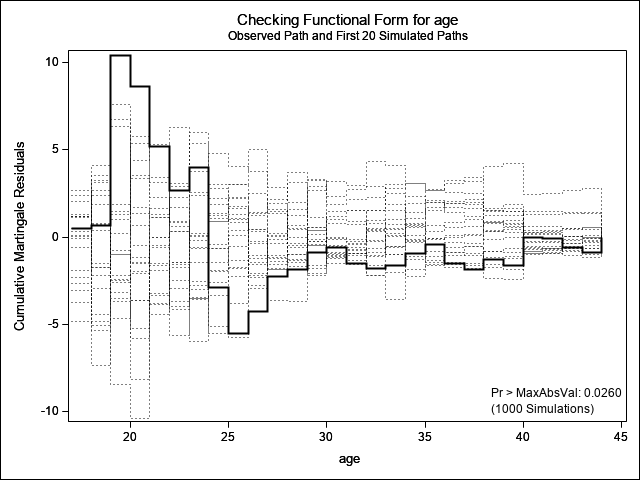

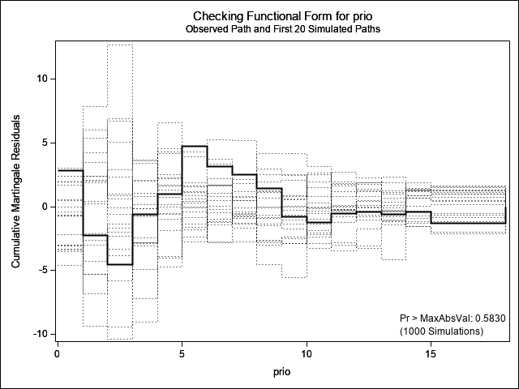

| Supremum Test for Functional Form Variable | Supremum Test for Functional Form Maximum Absolute Value | Supremum Test for Functional Form Replications | Supremum Test for Functional Form Seed | Supremum Test for Functional Form Pr > MaxAbsVal |
| --- | --- | --- | --- | --- |
| age | 10.4198 | 1000 | 1865732969 | 0.0260 |
| prio | 4.7269 | 1000 | 1865732969 | 0.5830 |